# AML - Phase 1: EDA

Autor:in

Luca Manna

Veröffentlichungsdatum

5. Juni 2026

```python
import os
import sys

import matplotlib.pyplot as plt
import numpy as np
import pandas as pd
import seaborn as sns
from matplotlib.patches import Patch
from sklearn.model_selection import train_test_split

# Projektroot für src-Importe
sys.path.insert(0, "..")

from src.data import (
    assign_pseudo_event_dates,
    extract_gender_and_birth,
    parse_date,
    set_plot_style,
)
```

```python
# === GLOBAL CONSTANTS ===
RANDOM_STATE = 42
FIG_SIZE_DEFAULT = (14, 6)
FIG_SIZE_LARGE = (16, 12)

# Raw Data Path
PATH_RAW = "../data/raw/"

# File Paths
PATH_RAW_ACCOUNT = PATH_RAW + "account.csv"
PATH_RAW_CARD = PATH_RAW + "card.csv"
PATH_RAW_CLIENT = PATH_RAW + "client.csv"
PATH_RAW_DISP = PATH_RAW + "disp.csv"
PATH_RAW_DISTRICT = PATH_RAW + "district.csv"
PATH_RAW_LOAN = PATH_RAW + "loan.csv"
PATH_RAW_ORDER = PATH_RAW + "order.csv"
PATH_RAW_TRANS = PATH_RAW + "trans.csv"

# Study Design Constants
ROLLUP_MONTHS = 12
LAG_MONTHS = 1
TOTAL_HISTORY_MONTHS = ROLLUP_MONTHS + LAG_MONTHS  # 13
JUNIOR_AGE_CUTOFF = 21  # max junior card holder age ≈ 20.89, derivation later in EDA

# Data Splits
TRAIN_RATIO = 0.8
TEST_RATIO = 0.2

# Initialize style on startup (imported from src.data)
set_plot_style()
```

# 1 Load Data

```python
account = pd.read_csv(PATH_RAW_ACCOUNT, sep=";")
card = pd.read_csv(PATH_RAW_CARD, sep=";")
client = pd.read_csv(PATH_RAW_CLIENT, sep=";")
disp = pd.read_csv(PATH_RAW_DISP, sep=";")
district = pd.read_csv(PATH_RAW_DISTRICT, sep=";")
loan = pd.read_csv(PATH_RAW_LOAN, sep=";")
order = pd.read_csv(PATH_RAW_ORDER, sep=";")
trans = pd.read_csv(PATH_RAW_TRANS, sep=";", low_memory=False)

print("Data loaded.")
```

```
Data loaded.
```

# 2 Datenstruktur verstehen

## 2.1 PK Check

Ausgabe von:

- Uniqueness
- Count
- Duplicates
- Missing
- Data Type für alle Tabellen

```python
def check_pk(df, pk_col, table_name):
    """Prüft ob eine Spalte als Primary Key geeignet ist (Uniqueness, Vollständigkeit, Datentyp)."""
    print(f"--- {table_name} (PK: {pk_col}) ---")
    print(f"  Unique:     {df[pk_col].is_unique}")
    print(f"  Count:      {df.shape[0]}")
    print(f"  Duplicates: {df[pk_col].duplicated().sum()}")
    print(f"  Missing:    {df[pk_col].isna().sum()}")
    print(f"  Dtype:      {df[pk_col].dtype}")
    print()


check_pk(account, "account_id", "Account")
check_pk(card, "card_id", "Card / Credit Card")
check_pk(client, "client_id", "Client")
check_pk(disp, "disp_id", "Disp / Disposition")
check_pk(district, "A1", "District / Demograph")
check_pk(loan, "loan_id", "Loan")
check_pk(order, "order_id", "Order / Permanent Order")
check_pk(trans, "trans_id", "Trans / Transactions")
```

```
--- Account (PK: account_id) ---
  Unique:     True
  Count:      4500
  Duplicates: 0
  Missing:    0
  Dtype:      int64

--- Card / Credit Card (PK: card_id) ---
  Unique:     True
  Count:      892
  Duplicates: 0
  Missing:    0
  Dtype:      int64

--- Client (PK: client_id) ---
  Unique:     True
  Count:      5369
  Duplicates: 0
  Missing:    0
  Dtype:      int64

--- Disp / Disposition (PK: disp_id) ---
  Unique:     True
  Count:      5369
  Duplicates: 0
  Missing:    0
  Dtype:      int64

--- District / Demograph (PK: A1) ---
  Unique:     True
  Count:      77
  Duplicates: 0
  Missing:    0
  Dtype:      int64

--- Loan (PK: loan_id) ---
  Unique:     True
  Count:      682
  Duplicates: 0
  Missing:    0
  Dtype:      int64

--- Order / Permanent Order (PK: order_id) ---
  Unique:     True
  Count:      6471
  Duplicates: 0
  Missing:    0
  Dtype:      int64

--- Trans / Transactions (PK: trans_id) ---
  Unique:     True
  Count:      1056320
  Duplicates: 0
  Missing:    0
  Dtype:      int64
```

### 2.1.1 Entschlüsse

- Alle Counts stimmen mit dem pdf überein
- Alle PK sind Unique
- Alle PK sind vorhanden
- Alle PK haben denselben Typ

> Bei district / Demographic ist die PK Spalte nicht `district_id` sonder `A1`. Diese Spalte wird von `A1` nach `district_id` umbenannt.

```python
district.rename(columns={"A1": "district_id"}, inplace=True)
district.head()
```

|  | district_id | A2 | A3 | A4 | A5 | A6 | A7 | A8 | A9 | A10 | A11 | A12 | A13 | A14 | A15 | A16 |
| --- | --- | --- | --- | --- | --- | --- | --- | --- | --- | --- | --- | --- | --- | --- | --- | --- |
| 0 | 1 | Hl.m. Praha | Prague | 1204953 | 0 | 0 | 0 | 1 | 1 | 100.0 | 12541 | 0.29 | 0.43 | 167 | 85677 | 99107 |
| 1 | 2 | Benesov | central Bohemia | 88884 | 80 | 26 | 6 | 2 | 5 | 46.7 | 8507 | 1.67 | 1.85 | 132 | 2159 | 2674 |
| 2 | 3 | Beroun | central Bohemia | 75232 | 55 | 26 | 4 | 1 | 5 | 41.7 | 8980 | 1.95 | 2.21 | 111 | 2824 | 2813 |
| 3 | 4 | Kladno | central Bohemia | 149893 | 63 | 29 | 6 | 2 | 6 | 67.4 | 9753 | 4.64 | 5.05 | 109 | 5244 | 5892 |
| 4 | 5 | Kolin | central Bohemia | 95616 | 65 | 30 | 4 | 1 | 6 | 51.4 | 9307 | 3.85 | 4.43 | 118 | 2616 | 3040 |

## 2.2 Kardinalitäten Check

Analyse wie die Tabellen zusammenhängen

```python
# Define all FK relationships: (fk_table, fk_col, pk_table, pk_col)
relations = [
    (
        account,
        "district_id",
        district,
        "district_id",
        "account.district_id -> district.district_id",
    ),
    (
        client,
        "district_id",
        district,
        "district_id",
        "client.district_id -> district.district_id",
    ),
    (disp, "client_id", client, "client_id", "disp.client_id -> client.client_id"),
    (
        disp,
        "account_id",
        account,
        "account_id",
        "disp.account_id -> account.account_id",
    ),
    (card, "disp_id", disp, "disp_id", "card.disp_id -> disp.disp_id"),
    (
        loan,
        "account_id",
        account,
        "account_id",
        "loan.account_id -> account.account_id",
    ),
    (
        order,
        "account_id",
        account,
        "account_id",
        "order.account_id -> account.account_id",
    ),
    (
        trans,
        "account_id",
        account,
        "account_id",
        "trans.account_id -> account.account_id",
    ),
]

rows = []
for fk_df, fk_col, pk_df, pk_col, label in relations:
    fk_values = fk_df[fk_col].dropna()
    pk_values = pk_df[pk_col]

    # Referential integrity: all FK values exist in PK?
    orphans = ~fk_values.isin(pk_values)

    # Cardinality: how many FK rows per PK value?
    counts = fk_values.value_counts()

    rows.append(
        {
            "Relation": label,
            "FK rows": len(fk_values),
            "FK nulls": fk_df[fk_col].isna().sum(),
            "Orphans": orphans.sum(),
            "PK used": fk_values.nunique(),
            "PK total": len(pk_values),
            "Min": counts.min(),
            "Max": counts.max(),
            "Median": counts.median(),
            "Cardinality": "1:1" if counts.max() == 1 else f"1:N (max {counts.max()})",
        }
    )

cardinality_df = pd.DataFrame(rows)
cardinality_df.style.set_properties(**{"text-align": "left"})
```

|  | Relation | FK rows | FK nulls | Orphans | PK used | PK total | Min | Max | Median | Cardinality |
| --- | --- | --- | --- | --- | --- | --- | --- | --- | --- | --- |
| 0 | account.district_id -> district.district_id | 4500 | 0 | 0 | 77 | 77 | 32 | 554 | 48.000000 | 1:N (max 554) |
| 1 | client.district_id -> district.district_id | 5369 | 0 | 0 | 77 | 77 | 43 | 663 | 56.000000 | 1:N (max 663) |
| 2 | disp.client_id -> client.client_id | 5369 | 0 | 0 | 5369 | 5369 | 1 | 1 | 1.000000 | 1:1 |
| 3 | disp.account_id -> account.account_id | 5369 | 0 | 0 | 4500 | 4500 | 1 | 2 | 1.000000 | 1:N (max 2) |
| 4 | card.disp_id -> disp.disp_id | 892 | 0 | 0 | 892 | 5369 | 1 | 1 | 1.000000 | 1:1 |
| 5 | loan.account_id -> account.account_id | 682 | 0 | 0 | 682 | 4500 | 1 | 1 | 1.000000 | 1:1 |
| 6 | order.account_id -> account.account_id | 6471 | 0 | 0 | 3758 | 4500 | 1 | 5 | 1.000000 | 1:N (max 5) |
| 7 | trans.account_id -> account.account_id | 1056320 | 0 | 0 | 4500 | 4500 | 9 | 675 | 208.000000 | 1:N (max 675) |

### 2.2.1 Erkenntnisse

- Keine Orphans und keine FK-Nulls -> referentielle Integrität ist vollständig gegeben
- **disp** ist die zentrale Brücken-Tabelle zwischen Client und Account

| Linke Seite | Beziehung | Rechte Seite |
| --- | --- | --- |
| district (1,1) | — (1,N) | account |
| district (1,1) | — (1,N) | client |
| client (1,1) | — (1,1) | disp |
| account (1,1) | — (1,2) | disp |
| disp (1,1) | — (0,1) | card |
| account (1,1) | — (0,1) | loan |
| account (1,1) | — (0,N) | order |
| account (1,1) | — (1,N) | trans |

Notation `(min,max)`: - `(0,1)` bedeutet optional bis zu einem zugeordneten Element. - `(1,N)` heisst mindestens ein Eintrag, ohne obere Schranke. - `(1,2)` ist eine harte Obergrenze von zwei (z.B. OWNER + optionaler DISPONENT pro Konto).

## 2.3 ERD

Das ERD wurde basierend auf den vorherigen Analysen erstellt.

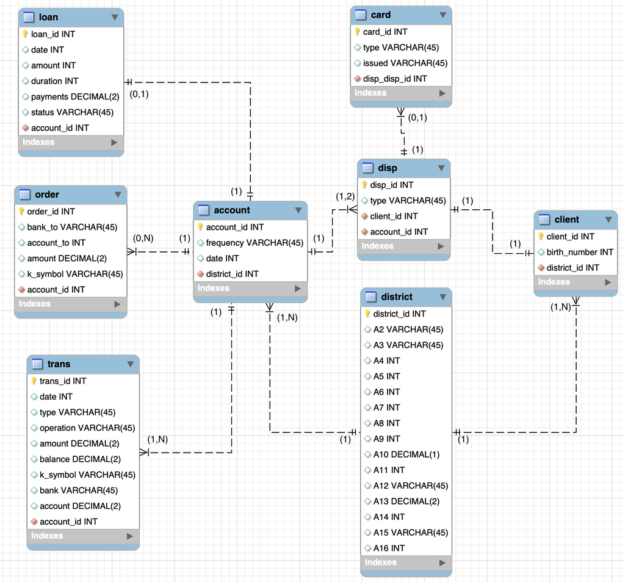

ERD Diagramm

## 2.4 Tabellenübersicht: Datentypen, Speicher & deskriptive Statistiken

Bevor wir in die Datenqualität einsteigen, verschaffen wir uns einen kompakten Überblick über alle Tabellen: Datentypen, Speicherverbrauch und die wichtigsten deskriptiven Kennzahlen der numerischen Spalten.

```python
# Dictionary aller DataFrames für einfachere Iteration (wird auch in späteren Zellen wiederverwendet)
dataframes = {
    "account": account,
    "client": client,
    "disp": disp,
    "district": district,
    "loan": loan,
    "order": order,
    "trans": trans,
    "card": card,
}

# Kompakte Übersicht aller Tabellen: Zeilen, Spalten, Datentypen und Speicherverbrauch
for name, df in dataframes.items():
    print(f"{'=' * 50}")
    print(f"Tabelle: {name.upper()} ({df.shape[0]} Zeilen, {df.shape[1]} Spalten)")
    print(f"{'=' * 50}")
    print(df.dtypes.to_string())
    print(f"\nSpeicher: {df.memory_usage(deep=True).sum() / 1e6:.1f} MB")
    print()

# Numerische Zusammenfassung der wichtigsten Tabellen
print("=== DESCRIBE: trans (numerische Spalten) ===")
print(trans.describe().round(1).to_string())
print()
print("=== DESCRIBE: loan ===")
print(loan.describe().round(1).to_string())
print()
print("=== DESCRIBE: district (demografische Kennzahlen) ===")
print(district.describe().round(1).to_string())
```

```
==================================================
Tabelle: ACCOUNT (4500 Zeilen, 4 Spalten)
==================================================
account_id     int64
district_id    int64
frequency        str
date           int64

Speicher: 0.2 MB

==================================================
Tabelle: CLIENT (5369 Zeilen, 3 Spalten)
==================================================
client_id       int64
birth_number    int64
district_id     int64

Speicher: 0.1 MB

==================================================
Tabelle: DISP (5369 Zeilen, 4 Spalten)
==================================================
disp_id       int64
client_id     int64
account_id    int64
type            str

Speicher: 0.2 MB

==================================================
Tabelle: DISTRICT (77 Zeilen, 16 Spalten)
==================================================
district_id      int64
A2                 str
A3                 str
A4               int64
A5               int64
A6               int64
A7               int64
A8               int64
```

[output cut: 79 more lines]

```
25%     5577.5      2967.0  950704.5   66732.0      24.0    2477.0
50%     6176.5      5738.5  970206.5  116928.0      36.0    3934.0
75%     6752.5      8686.0  971212.5  210654.0      48.0    5813.5
max     7308.0     11362.0  981208.0  590820.0      60.0    9910.0

=== DESCRIBE: district (demografische Kennzahlen) ===
       district_id         A4     A5    A6    A7    A8    A9    A10      A11   A13    A14      A16
count         77.0       77.0   77.0  77.0  77.0  77.0  77.0   77.0     77.0  77.0   77.0     77.0
mean          39.0   133884.9   48.6  24.3   6.3   1.7   6.3   63.0   9031.7   3.8  116.1   5030.8
std           22.4   136913.5   32.7  12.8   4.0   1.0   2.4   16.2    790.2   1.9   16.6  11270.8
min            1.0    42821.0    0.0   0.0   0.0   0.0   1.0   33.9   8110.0   0.4   81.0    888.0
25%           20.0    85852.0   22.0  16.0   4.0   1.0   5.0   51.9   8512.0   2.3  105.0   2122.0
50%           39.0   108871.0   49.0  25.0   6.0   2.0   6.0   59.8   8814.0   3.6  113.0   3040.0
75%           58.0   139012.0   71.0  32.0   8.0   2.0   8.0   73.5   9317.0   4.8  126.0   4595.0
max           77.0  1204953.0  151.0  70.0  20.0   5.0  11.0  100.0  12541.0   9.4  167.0  99107.0
```

### 2.4.1 Erkenntnisse

Die Transaktionstabelle (`trans`) dominiert mit 1.06 Mio. Zeilen und 100.5 MB den Datensatz bei weitem. Alle anderen Tabellen zusammen belegen weniger als 1 MB. Sie ist damit die primäre Datenquelle für das spätere Feature Engineering.

Mehrere Datumsspalten (`account.date`, `loan.date`, `trans.date`) liegen noch im Format YYMMDD als Integer vor und werden im nächsten Schritt in `datetime` konvertiert. Das Feld `card.issued` ist als String gespeichert und enthält teils angehängte Stunden.

Die `district`-Tabelle enthält kryptische Spaltennamen (A1 bis A16). Die für das Modell relevanten Felder sind Durchschnittsgehalt (A11: 8110 bis 12541 CZK), Arbeitslosenquote (A13: 0.4% bis 9.4%) und Urbanisierungsgrad (A10: 33.9% bis 100%). Die starke Streuung der Einwohnerzahl (A4: 42821 bis 1204953) zeigt den Grössenunterschied zwischen Prag und ländlichen Bezirken.

Zwei Auffälligkeiten aus `trans.describe()`:

- Kontostände können negativ werden (Minimum: 41125 CZK im Minus), d.h. Überziehungskredite sind im Datensatz vorhanden.
- Transaktionsbeträge sind stark rechtsschief (Median 2100 CZK gegenüber Mittelwert 5924 CZK), was auf vereinzelte sehr grosse Transaktionen hindeutet.

Kreditlaufzeiten in `loan` bewegen sich zwischen 12 und 60 Monaten, Kreditbeträge zwischen 4980 und 590820 CZK.

# 3 Datenqualität und vorbereitende Exploration

## 3.1 Datenqualität pro Tabelle

```python
print("=== CHECK AUF DUPLIKATE & FEHLENDE WERTE ===")
for name, df in dataframes.items():
    duplicates = df.duplicated().sum()
    missing_cols = df.isnull().sum()
    missing_cols = missing_cols[missing_cols > 0]

    print(f"Tabelle: {name.upper()}")
    print(f"  Duplikate gefunden: {duplicates}")
    if len(missing_cols) > 0:
        print(f"  Fehlende Werte (Achtung!):\n{missing_cols.to_string()}")
    else:
        print("  Keine fehlenden Werte.")
    print("-" * 40)
```

```
=== CHECK AUF DUPLIKATE & FEHLENDE WERTE ===
Tabelle: ACCOUNT
  Duplikate gefunden: 0
  Keine fehlenden Werte.
----------------------------------------
Tabelle: CLIENT
  Duplikate gefunden: 0
  Keine fehlenden Werte.
----------------------------------------
Tabelle: DISP
  Duplikate gefunden: 0
  Keine fehlenden Werte.
----------------------------------------
Tabelle: DISTRICT
  Duplikate gefunden: 0
  Keine fehlenden Werte.
----------------------------------------
Tabelle: LOAN
  Duplikate gefunden: 0
  Keine fehlenden Werte.
----------------------------------------
Tabelle: ORDER
  Duplikate gefunden: 0
  Keine fehlenden Werte.
----------------------------------------
Tabelle: TRANS
  Duplikate gefunden: 0
  Fehlende Werte (Achtung!):
operation    183114
k_symbol     481881
bank         782812
account      760931
----------------------------------------
Tabelle: CARD
  Duplikate gefunden: 0
  Keine fehlenden Werte.
----------------------------------------
```

### 3.1.1 Erkenntnisse

7 von 8 Tabellen weisen weder Duplikate noch fehlende Werte auf. Die Datenqualität ist damit insgesamt hoch.

Einzige Ausnahme ist `trans` mit vier betroffenen Spalten: `operation` (183114 NaN, ca. 17%), `k_symbol` (481881 NaN, ca. 46%), `bank` (782812 NaN, ca. 74%) und `account` (760931 NaN, ca. 72%). Die hohen Anteile deuten auf strukturell bedingte Lücken hin und nicht auf zufällige Datenfehler. Die detaillierte Analyse folgt im nächsten Abschnitt.

### 3.1.2 Analyse fehlender Werte in `trans`

Die Tabelle `trans` ist die einzige mit fehlenden Werten. Vier Spalten sind betroffen: `operation` (17%), `k_symbol` (46%), `bank` (74%) und `account` (72%). Bevor wir diese Werte im Feature Engineering behandeln, müssen wir verstehen, ob es sich um **strukturelle** (systembedingte) oder **zufällige** Lücken handelt. Dazu analysieren wir die Verteilung der NaNs in Abhängigkeit vom Transaktionstyp (`type`) und der Transaktionsart (`operation`).

```python
missing_cols = ["operation", "k_symbol", "bank", "account"]

# 1. NaN-Anteil pro Spalte nach Transaktionstyp (type: credit / withdrawal)
print("=== NaN-Anteil (%) nach Transaktionstyp ===")
for col in missing_cols:
    nan_by_type = (
        trans.groupby("type")[col].apply(lambda x: x.isna().mean() * 100).round(1)
    )
    print(f"\n{col}:")
    print(nan_by_type.to_string())

# 2. NaN-Anteil pro Spalte nach Operation
print("\n\n=== NaN-Anteil (%) nach Operation ===")
for col in missing_cols:
    # operation selbst hat NaNs, daher fillna für die Gruppierung
    nan_by_op = (
        trans.assign(operation_group=trans["operation"].fillna("(NaN)"))
        .groupby("operation_group")[col]
        .apply(lambda x: x.isna().mean() * 100)
        .round(1)
        .sort_values(ascending=False)
    )
    print(f"\n{col}:")
    print(nan_by_op.to_string())

# 3. Kompakte Kreuztabelle: Wie viele Transaktionen pro operation haben bank/account?
print(
    "\n\n=== Transaktionen pro Operation: Anzahl und NaN-Anteil für bank & account ==="
)
op_summary = (
    trans.assign(operation_group=trans["operation"].fillna("(NaN)"))
    .groupby("operation_group")
    .agg(
        n=("trans_id", "count"),
        bank_nan_pct=("bank", lambda x: round(x.isna().mean() * 100, 1)),
        account_nan_pct=("account", lambda x: round(x.isna().mean() * 100, 1)),
        k_symbol_nan_pct=("k_symbol", lambda x: round(x.isna().mean() * 100, 1)),
    )
    .sort_values("n", ascending=False)
)
print(op_summary.to_string())
```

```
=== NaN-Anteil (%) nach Transaktionstyp ===

operation:
type
PRIJEM    45.2
VYBER      0.0
VYDAJ      0.0

k_symbol:
type
PRIJEM     47.3
VYBER     100.0
VYDAJ      43.1

bank:
type
PRIJEM     83.9
VYBER     100.0
VYDAJ      67.2

account:
type
PRIJEM     83.9
VYBER     100.0
VYDAJ      63.7


=== NaN-Anteil (%) nach Operation ===

operation:
operation_group
(NaN)             100.0
PREVOD NA UCET      0.0
PREVOD Z UCTU       0.0
VKLAD               0.0
VYBER               0.0
VYBER KARTOU        0.0

k_symbol:
operation_group
```

[output cut: 20 more lines]

```
VYBER              96.8
PREVOD NA UCET      0.0
PREVOD Z UCTU       0.0
VYBER KARTOU        0.0


=== Transaktionen pro Operation: Anzahl und NaN-Anteil für bank & account ===
                      n  bank_nan_pct  account_nan_pct  k_symbol_nan_pct
operation_group
VYBER            434918         100.0             96.8              63.0
PREVOD NA UCET   208283           0.0              0.0               3.9
(NaN)            183114         100.0            100.0               0.0
VKLAD            156743         100.0            100.0             100.0
PREVOD Z UCTU     65226           0.0              0.0              53.5
VYBER KARTOU       8036         100.0              0.0             100.0
```

### 3.1.3 Erkenntnisse zu fehlenden Werten in `trans`

**Konsequenz für das Feature Engineering:** Die NaNs können nicht sinnvoll imputiert werden, da sie “kein Wert vorhanden” bedeuten (z.B. eine Bareinzahlung hat schlicht keine Partnerbank). Stattdessen sollten sie als eigene Kategorie behandelt oder bei der Aggregation ignoriert werden. Die Anzahl der Transaktionen *mit* vs. *ohne* Partnerbank könnte selbst ein nützliches Feature sein.

### 3.1.4 Kategorien decodieren

Viele Datenpunkte in den Tabellen `account`, `trans` und `order` enthalten tschechische Strings. Um die Übersichtlichkeit und das Feature Engineering später zu vereinfachen, werden diese Begriffe entsprechend der Dokumentation (`00_data_desc.md`) ins Englische übersetzt.

```python
# Mappings basierend auf 00_data_desc.md

freq_mapping = {
    "POPLATEK MESICNE": "monthly",
    "POPLATEK TYDNE": "weekly",
    "POPLATEK PO OBRATU": "after transaction",
}
account["frequency"] = account["frequency"].map(freq_mapping)

trans_type_mapping = {"PRIJEM": "credit", "VYDAJ": "withdrawal"}
trans["type"] = trans["type"].map(trans_type_mapping)

trans_op_mapping = {
    "VYBER KARTOU": "credit_card_withdrawal",
    "VKLAD": "credit_in_cash",
    "PREVOD Z UCTU": "collection_from_another_bank",
    "VYBER": "withdrawal_in_cash",
    "PREVOD NA UCET": "remittance_to_another_bank",
}
trans["operation"] = (
    trans["operation"].map(trans_op_mapping).fillna(trans["operation"])
)  # NaN bei Zinsgutschriften belassen oder String ändern

k_symbol_mapping = {
    "POJISTNE": "insurance_payment",
    "SIPO": "household_payment",
    "LEASING": "leasing",
    "UVER": "loan_payment",
    "SLUZBY": "payment_for_statement",
    "UROK": "interest_credited",
    "SANKC. UROK": "sanction_interest",
    "DUCHOD": "old_age_pension",
}
trans["k_symbol"] = trans["k_symbol"].map(k_symbol_mapping).fillna(trans["k_symbol"])
order["k_symbol"] = order["k_symbol"].map(k_symbol_mapping).fillna(order["k_symbol"])

print("Tschechische Begriffe in `account`, `trans` und `order` erfolgreich decodiert!")
```

```
Tschechische Begriffe in `account`, `trans` und `order` erfolgreich decodiert!
```

### 3.1.5 Geburtsdatum und Geschlecht extrahieren

In der `client` Tabelle ist das Geschlecht im Geburtsdatum (`birth_number`) einkodiert. Bei Frauen wird der Zahl für den Monat der Wert 50 hinzugefügt. Wir splitten dies in zwei separate Spalten `gender` (M/F) und `birth_date` auf und entfernen die alte kryptische Spalte.

```python
# extract_gender_and_birth ist aus src.data importiert
client[["gender", "birth_date"]] = client["birth_number"].apply(
    extract_gender_and_birth
)

# Vorherige Spalte droppen
client = client.drop(columns=["birth_number"])

client.head(3)
```

|  | client_id | district_id | gender | birth_date |
| --- | --- | --- | --- | --- |
| 0 | 1 | 18 | F | 1970-12-13 |
| 1 | 2 | 1 | M | 1945-02-04 |
| 2 | 3 | 1 | F | 1940-10-09 |

### 3.1.6 Datentypen korrigieren & Zeitliche Abdeckung überprüfen

Aktuell liegen in mehreren Tabellen Datumsangaben im Format `YYMMDD` als Integer oder String vor. Wir konvertieren diese in aussagekräftige `datetime` Objekte. Bei der Tabelle `card` sind teils noch Stunden an das Datum gehängt, weshalb wir explizit nur die ersten 6 Zeichen (`str[:6]`) für die Datumsextraktion nutzen. Gleichzeitig prüfen wir den minimalen und maximalen Zeitraum, um eine Vorstellung über das Gesamthistorien-Fenster zu erhalten.

```python
# parse_date ist aus src.data importiert
account["date"] = parse_date(account["date"])
card["issued"] = parse_date(card["issued"])
loan["date"] = parse_date(loan["date"])
trans["date"] = parse_date(trans["date"])

print("\n=== ZEITLICHE ABDECKUNG (MIN - MAX) ===")
print(
    f"Account Eröffnungen:  {account['date'].dt.date.min()}  bis  {account['date'].dt.date.max()}"
)
print(
    f"Transaktionen:        {trans['date'].dt.date.min()}  bis  {trans['date'].dt.date.max()}"
)
print(
    f"Kreditvergabe:        {loan['date'].dt.date.min()}  bis  {loan['date'].dt.date.max()}"
)
print(
    f"Karten Ausstellungen: {card['issued'].dt.date.min()}  bis  {card['issued'].dt.date.max()}"
)

# Variablen für die zukünftige Berechnung des Baseline rollups
min_global_date = trans["date"].min()
max_global_date = trans["date"].max()
total_months_available = (
    (max_global_date.year - min_global_date.year) * 12
    + max_global_date.month
    - min_global_date.month
)
print(f"\n=> Gesamte Transaktionshistorie umfasst ca. {total_months_available} Monate.")
```

```
=== ZEITLICHE ABDECKUNG (MIN - MAX) ===
Account Eröffnungen:  1993-01-01  bis  1997-12-29
Transaktionen:        1993-01-01  bis  1998-12-31
Kreditvergabe:        1993-07-05  bis  1998-12-08
Karten Ausstellungen: 1993-11-07  bis  1998-12-29

=> Gesamte Transaktionshistorie umfasst ca. 71 Monate.
```

# 4 Exploration der Basisdaten

In diesem Kapitel untersuchen wir systematisch jede Tabelle des Datensatzes, bevor wir zum Feature Engineering übergehen. Ziel ist ein fundiertes Verständnis der Verteilungen, Muster und potenziellen Prädiktoren für das Kreditkarten-Affinitätsmodell.

## 4.1 Exploration der Kontodaten (account)

Wir beginnen mit der `account` Tabelle, da Konten die zentrale Einheit für unsere Analyse darstellen. Jede Kreditkarte wird über eine Disposition einem Konto zugeordnet. Wir untersuchen die Verteilung der Kontoauszugs-Frequenzen und die zeitliche Verteilung der Kontoeröffnungen.

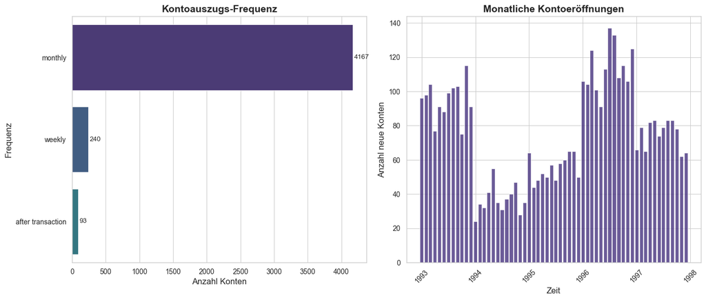

```
Account Stichprobe:
 account_id  district_id frequency       date
       2243           25   monthly 1996-01-24
       1616           22   monthly 1997-02-07
       3543           74   monthly 1996-07-21
```

```python
fig, axes = plt.subplots(1, 2, figsize=FIG_SIZE_DEFAULT)

# 1. Kontoauszugs-Frequenz
freq_counts = account["frequency"].value_counts()
sns.barplot(
    x=freq_counts.values,
    y=freq_counts.index,
    hue=freq_counts.index,
    ax=axes[0],
)
axes[0].set_title("Kontoauszugs-Frequenz")
axes[0].set_xlabel("Anzahl Konten")
axes[0].set_ylabel("Frequenz")
for i, v in enumerate(freq_counts.values):
    axes[0].text(v + 20, i, str(v), va="center")

# 2. Kontoeröffnungen über die Zeit (monatlich)
# Ensure account["date"] is datetime (handled in load cell now)
account["open_month"] = account["date"].dt.to_period("M").dt.to_timestamp()
monthly_openings = account.groupby("open_month").size()
axes[1].bar(
    monthly_openings.index,
    monthly_openings.values,
    width=25,
    alpha=0.8,
)
axes[1].set_title("Monatliche Kontoeröffnungen")
axes[1].set_xlabel("Zeit")
axes[1].set_ylabel("Anzahl neue Konten")
axes[1].tick_params(axis="x", rotation=45)

plt.tight_layout()
plt.show()

print("Account Stichprobe:")
print(
    account[["account_id", "district_id", "frequency", "date"]]
    .sample(3, random_state=RANDOM_STATE)
    .to_string(index=False)
)
```

### 4.1.1 Erkenntnisse

92.6% der Konten (4167 von 4500) verwenden den monatlichen Kontoauszug. Wöchentliche (240) und transaktionsbasierte (93) Auszüge sind selten. Die Kontoauszugs-Frequenz ist ein explizit gefordertes Baseline-Feature und fliesst als Indikatorvariable ins Modell ein.

## 4.2 Exploration der Kundendaten (client)

Die `client` Tabelle enthält Alter und Geschlecht (bereits aus `birth_number` extrahiert). Für das Baseline-Modell sind “Alter” und “Geschlecht” explizit geforderte Features. Wir untersuchen deren Verteilungen.

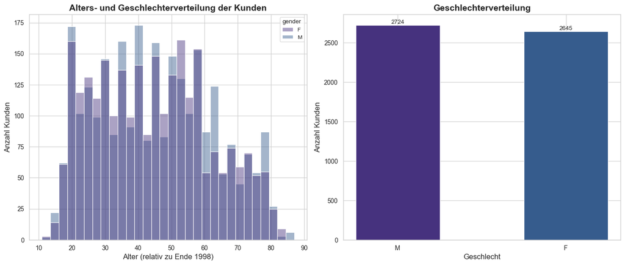

```
Altersstatistik:
count    5369.0
mean       44.8
std        17.3
min        11.0
25%        30.0
50%        44.0
75%        58.0
max        87.0
Name: age, dtype: float64

Geschlechterverteilung:
gender
M    2724
F    2645
Name: count, dtype: int64
```

```python
# Alter berechnen (Ende 1998 als Analyse-Zeitpunkt der gesamten Historie)
max_date = trans["date"].max()
client["age"] = (max_date - client["birth_date"]).dt.days // 365

fig, axes = plt.subplots(1, 2, figsize=FIG_SIZE_DEFAULT)

# 1. Alters- und Geschlechterverteilung (überlappend, transparent)
sns.histplot(
    data=client,
    x="age",
    hue="gender",
    multiple="layer",  # statt "stack"
    bins=30,
    alpha=0.45,  # Transparenz für Überlappung
    ax=axes[0],
)
axes[0].set_title("Alters- und Geschlechterverteilung der Kunden")
axes[0].set_xlabel("Alter (relativ zu Ende 1998)")
axes[0].set_ylabel("Anzahl Kunden")

# 2. Geschlechterverteilung
gender_counts = client["gender"].value_counts()
axes[1].bar(gender_counts.index, gender_counts.values, color=["C0", "C1"], width=0.5)
axes[1].set_title("Geschlechterverteilung")
axes[1].set_xlabel("Geschlecht")
axes[1].set_ylabel("Anzahl Kunden")
for i, v in enumerate(gender_counts.values):
    axes[1].text(i, v + 20, str(v), ha="center")

plt.tight_layout()
plt.show()

print("Altersstatistik:")
print(client["age"].describe().round(1))
print(f"\nGeschlechterverteilung:\n{gender_counts}")
```

### 4.2.1 Erkenntnisse

Das Alter ist relativ zum Ende der Transaktionshistorie (Ende 1998) berechnet. Die Verteilung erstreckt sich von 11 bis 87 Jahre (Median 44, Mittelwert 44.8). Das Minimum von 11 Jahren zeigt, dass Minderjährige im Datensatz vorhanden sind. Diese Gruppe ist für das Kreditkartenmodell nicht relevant und wird im Studiendesign über den Alters-Cutoff von 21 Jahren ausgeschlossen.

Die Altersverteilung ist im Bereich 20 bis 60 Jahre annähernd gleichmässig, mit einem leichten Häufigkeitsabfall nach dem 60. Lebensjahr.

Die Geschlechterverteilung ist nahezu ausgeglichen (M: 2724, F: 2645). Ein systematischer Gender-Bias in der Kundenbasis ist nicht vorhanden. Beide Merkmale sind explizit geforderte Baseline-Features für das Modell.

## 4.3 Exploration der Dispositionsdaten (disp)

Die `disp` Tabelle verbindet Kunden mit Konten und definiert deren Berechtigungsstufe (Owner vs. User). Nur Owner dürfen Daueraufträge erteilen und Kredite beantragen. Für die Kreditkarten-Analyse ist relevant, wie viele Konten Owner vs. User haben und wie viele Konten von mehreren Personen geteilt werden.

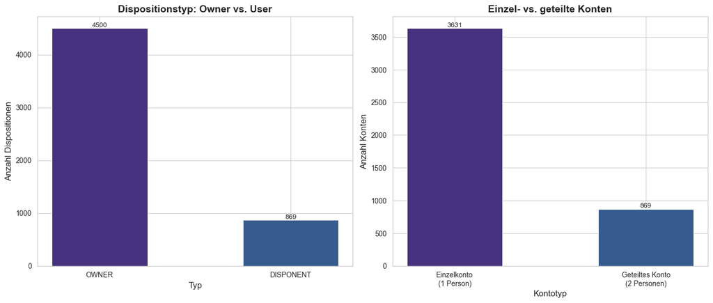

```
Konten mit genau 1 Disposition (Einzelkonto): 3631
Konten mit 2 Dispositionen (geteiltes Konto): 869
```

```python
fig, axes = plt.subplots(1, 2, figsize=FIG_SIZE_DEFAULT)

# 1. Owner vs. User Verteilung
disp_type_counts = disp["type"].value_counts()
axes[0].bar(
    disp_type_counts.index,
    disp_type_counts.values,
    color=["C0", "C1"],
    width=0.5,
)
axes[0].set_title("Dispositionstyp: Owner vs. User")
axes[0].set_xlabel("Typ")
axes[0].set_ylabel("Anzahl Dispositionen")
for i, v in enumerate(disp_type_counts.values):
    axes[0].text(i, v + 20, str(v), ha="center")

# 2. Anzahl Dispositionen pro Konto (wie viele Konten werden geteilt?)
disps_per_account = disp.groupby("account_id").size().value_counts().sort_index()
labels = {1: "Einzelkonto\n(1 Person)", 2: "Geteiltes Konto\n(2 Personen)"}
x_labels = [labels.get(k, str(k)) for k in disps_per_account.index]
axes[1].bar(x_labels, disps_per_account.values, color=["C0", "C1"], width=0.5)
axes[1].set_title("Einzel- vs. geteilte Konten")
axes[1].set_xlabel("Kontotyp")
axes[1].set_ylabel("Anzahl Konten")
for i, v in enumerate(disps_per_account.values):
    axes[1].text(i, v + 20, str(v), ha="center")

plt.tight_layout()
plt.show()

shared_accounts = (disp.groupby("account_id").size() > 1).sum()
print(
    f"Konten mit genau 1 Disposition (Einzelkonto): {(disp.groupby('account_id').size() == 1).sum()}"
)
print(f"Konten mit 2 Dispositionen (geteiltes Konto): {shared_accounts}")
```

Die disp Tabelle hat 5369 Einträge - einen pro Kunde. Jeder Eintrag verknüpft einen Kunden mit einem Konto und gibt ihm eine Rolle:

- OWNER = Kontoinhaber (darf alles: Daueraufträge, Kredite etc.)
- DISPONENT = Mitbenutzer (eingeschränkte Rechte, z.B. Partner)

Die 4500 Konten verteilen sich so:

- Einzelkonto: 1 Disposition = nur 1 Owner, keine zweite Person
- Geteiltes Konto: 2 Dispositionen = 1 Owner + 1 Disponent auf demselben Konto

## 4.4 Exploration der Regionaldaten (district)

Die `district` Tabelle liefert demografische Kennzahlen der 77 Bezirke. “Domizilregion” ist ein gefordertes Baseline-Feature. Wir untersuchen die Verteilungen der wichtigsten Variablen: Durchschnittsgehalt (`A11`), Arbeitslosenquote (`A13`), Urbanisierungsgrad (`A10`) und die Anzahl Kunden pro Bezirk.

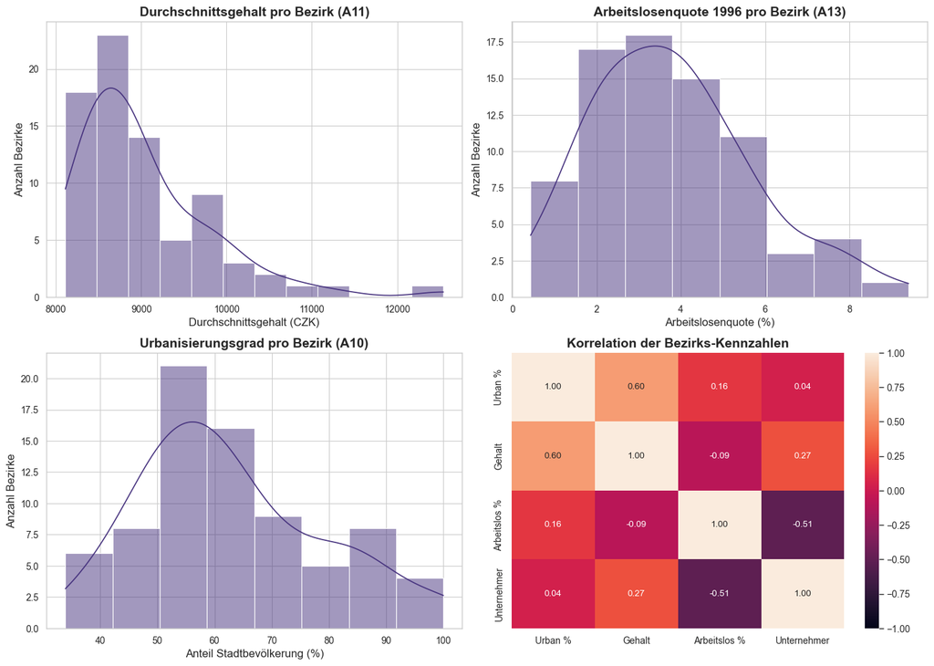

```
Top-10 Bezirke nach Anzahl Konten:
district_id
1     554
70    152
74    135
54    128
64     92
72     88
68     83
5      65
46     59
52     57
```

```python
fig, axes = plt.subplots(2, 2, figsize=(14, 10))

# 1. Durchschnittsgehälter
sns.histplot(district["A11"], kde=True, ax=axes[0, 0])
axes[0, 0].set_title("Durchschnittsgehalt pro Bezirk (A11)")
axes[0, 0].set_xlabel("Durchschnittsgehalt (CZK)")
axes[0, 0].set_ylabel("Anzahl Bezirke")

# 2. Arbeitslosenquote
sns.histplot(district["A13"], kde=True, ax=axes[0, 1])
axes[0, 1].set_title("Arbeitslosenquote 1996 pro Bezirk (A13)")
axes[0, 1].set_xlabel("Arbeitslosenquote (%)")
axes[0, 1].set_ylabel("Anzahl Bezirke")

# 3. Urbanisierungsgrad
sns.histplot(district["A10"], kde=True, ax=axes[1, 0])
axes[1, 0].set_title("Urbanisierungsgrad pro Bezirk (A10)")
axes[1, 0].set_xlabel("Anteil Stadtbevölkerung (%)")
axes[1, 0].set_ylabel("Anzahl Bezirke")

# 4. Korrelation der wichtigsten Bezirksvariablen
district_features = district[["A10", "A11", "A13", "A14"]].rename(
    columns={
        "A10": "Urban %",
        "A11": "Gehalt",
        "A13": "Arbeitslos %",
        "A14": "Unternehmer",
    }
)
sns.heatmap(
    district_features.corr(),
    annot=True,
    fmt=".2f",
    ax=axes[1, 1],
    vmin=-1,
    vmax=1,
)
axes[1, 1].set_title("Korrelation der Bezirks-Kennzahlen")

plt.tight_layout()
plt.show()

# Anzahl Konten pro Bezirk (Top 10)
accounts_per_district = (
    account.groupby("district_id").size().sort_values(ascending=False)
)
print("Top-10 Bezirke nach Anzahl Konten:")
print(accounts_per_district.head(10).to_string())
```

### 4.4.1 Erkenntnisse

Prag (district_id 1) dominiert die Kontoverteilung mit 554 Konten und ist damit mehr als dreimal so gross wie der zweitgrösste Bezirk (district_id 70 mit 152). Prag ist auch der Ausreisser im Durchschnittsgehalt (~12500 CZK gegenüber dem Median von 8814 CZK aller Bezirke).

Das Durchschnittsgehalt (A11) ist rechtsschief verteilt. Die grosse Mehrheit der Bezirke liegt zwischen 8000 und 9500 CZK. Die Arbeitslosenquote (A13) ist ebenfalls rechtsschief mit einem Median von ca. 3.6%.

Aus der Korrelationsmatrix sind zwei Zusammenhänge relevant für das Feature Engineering: Urbanisierungsgrad und Durchschnittsgehalt korrelieren moderat positiv (0.60), d.h. städtischere Bezirke haben tendenziell höhere Löhne. Unternehmerdichte und Arbeitslosenquote korrelieren negativ (0.51), was ökonomisch plausibel ist. Diese Kollinearität ist beim Einsatz beider Features im Modell zu beachten.

## 4.5 Exploration der Transaktionsdaten (trans)

Die `trans` Tabelle ist mit über 1 Mio. Einträgen die grösste und wichtigste Datenquelle für das Feature Engineering. Transaktionsmuster vor dem Kreditkartenkauf bilden die Grundlage des Rollup-Zeitfensters. Wir analysieren die zeitliche Verteilung, Transaktionstypen und -volumina, Verwendungszwecke sowie die Saldenentwicklung.

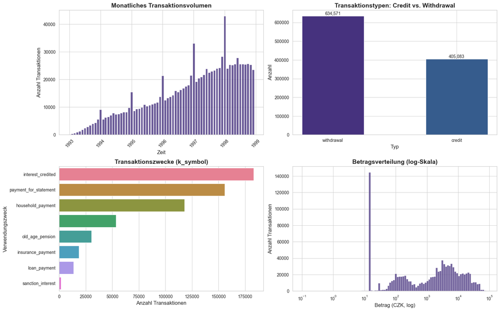

```
Verteilung der Operationsmodi:
operation
withdrawal_in_cash              434918
remittance_to_another_bank      208283
NaN                             183114
credit_in_cash                  156743
collection_from_another_bank     65226
credit_card_withdrawal            8036
```

```python
fig, axes = plt.subplots(2, 2, figsize=(16, 10))

# 1. Transaktionsvolumen über die Zeit (monatlich)
# Ensure date is datetime (handled in load cell)
trans["trans_month"] = trans["date"].dt.to_period("M").dt.to_timestamp()
monthly_trans = trans.groupby("trans_month").size()
axes[0, 0].bar(monthly_trans.index, monthly_trans.values, width=25, alpha=0.8)
axes[0, 0].set_title("Monatliches Transaktionsvolumen")
axes[0, 0].set_xlabel("Zeit")
axes[0, 0].set_ylabel("Anzahl Transaktionen")
axes[0, 0].tick_params(axis="x", rotation=45)

# 2. Credit vs. Withdrawal
type_counts = trans["type"].value_counts()
axes[0, 1].bar(
    type_counts.index,
    type_counts.values,
    color=["C0", "C1"],  # Credit vs Withdrawal - Use Theme Cycle colors 1 & 2
    width=0.5,
)
axes[0, 1].set_title("Transaktionstypen: Credit vs. Withdrawal")
axes[0, 1].set_xlabel("Typ")
axes[0, 1].set_ylabel("Anzahl")
for i, v in enumerate(type_counts.values):
    axes[0, 1].text(i, v + 5000, f"{v:,}", ha="center", fontsize=10)

# 3. Transaktionszwecke (k_symbol, ohne NaN)
valid_ksymbols = trans.dropna(subset=["k_symbol"])
ksym_counts = valid_ksymbols["k_symbol"].value_counts()
sns.barplot(
    x=ksym_counts.values,
    y=ksym_counts.index,
    hue=ksym_counts.index,
    ax=axes[1, 0],
)
axes[1, 0].set_title("Transaktionszwecke (k_symbol)")
axes[1, 0].set_xlabel("Anzahl Transaktionen")
axes[1, 0].set_ylabel("Verwendungszweck")

# 4. Betragsverteilung (log-Skala)
sns.histplot(trans["amount"], bins=100, ax=axes[1, 1], log_scale=(True, False))
axes[1, 1].set_title("Betragsverteilung (log-Skala)")
axes[1, 1].set_xlabel("Betrag (CZK, log)")
axes[1, 1].set_ylabel("Anzahl Transaktionen")

plt.tight_layout()
plt.show()

# Operationsmodus-Verteilung
print("Verteilung der Operationsmodi:")
print(trans["operation"].value_counts(dropna=False).to_string())
```

### 4.5.1 Erkenntnisse

Wie erwartet überwiegen Auszahlungen (withdrawal: 634571, 60%) gegenüber Gutschriften (credit: 405083, 38%). Konten werden primär zum Ausgeben genutzt.

Bei den Operationsmodi dominiert `withdrawal_in_cash` mit 435000 Einträgen (41%). Die 183114 NaN-Einträge entsprechen Systemtransaktionen ohne explizite Kundenoperation (z.B. Zinsgutschriften) und wurden bereits als strukturelle NaNs identifiziert. `credit_card_withdrawal` ist mit 8036 Einträgen (0.8%) sehr selten und signalisiert bereits existierende Kreditkartennutzung in der Kundenbasis.

Die Betragsverteilung ist auf der log-Skala bimodal: ein schmaler Spike bei sehr kleinen Beträgen (ca. 10 bis 20 CZK, vermutlich Zinsbuchungen) und die Hauptmasse zwischen 100 und 100000 CZK. Grosse Einzelbeträge bis 87400 CZK kommen vor, sind aber selten.

## 4.6 Exploration der Kreditdaten (loan)

Die `loan` Tabelle beschreibt vergebene Kredite. Ob ein Kunde bereits einen Kredit hat, ist ein potenzielles Feature für das Affinitätsmodell. Wir untersuchen Kreditbeträge, Laufzeiten, Vertragsstatus und die zeitliche Verteilung der Kreditvergaben.

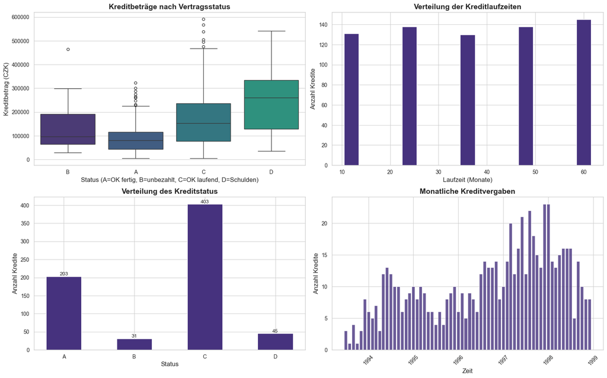

```
Anzahl Kredite total: 682

Statusverteilung:
status
A    203
B     31
C    403
D     45
Name: count, dtype: int64
```

```python
fig, axes = plt.subplots(2, 2, figsize=(16, 10))

# 1. Kreditbeträge nach Status
sns.boxplot(
    data=loan,
    x="status",
    y="amount",
    hue="status",
    ax=axes[0, 0],
)
axes[0, 0].set_title("Kreditbeträge nach Vertragsstatus")
axes[0, 0].set_xlabel("Status (A=OK fertig, B=unbezahlt, C=OK laufend, D=Schulden)")
axes[0, 0].set_ylabel("Kreditbetrag (CZK)")

# 2. Laufzeitverteilung
duration_counts = loan["duration"].value_counts().sort_index()
axes[0, 1].bar(duration_counts.index, duration_counts.values, width=3)
axes[0, 1].set_title("Verteilung der Kreditlaufzeiten")
axes[0, 1].set_xlabel("Laufzeit (Monate)")
axes[0, 1].set_ylabel("Anzahl Kredite")

# 3. Statusverteilung
status_counts = loan["status"].value_counts().sort_index()
axes[1, 0].bar(status_counts.index, status_counts.values, width=0.5)
axes[1, 0].set_title("Verteilung des Kreditstatus")
axes[1, 0].set_xlabel("Status")
axes[1, 0].set_ylabel("Anzahl Kredite")
for i, v in enumerate(status_counts.values):
    axes[1, 0].text(i, v + 3, str(v), ha="center")

# 4. Zeitliche Verteilung der Kreditvergaben
# date is datetime
loan["loan_month"] = loan["date"].dt.to_period("M").dt.to_timestamp()
monthly_loans = loan.groupby("loan_month").size()
axes[1, 1].bar(monthly_loans.index, monthly_loans.values, width=25, alpha=0.8)
axes[1, 1].set_title("Monatliche Kreditvergaben")
axes[1, 1].set_xlabel("Zeit")
axes[1, 1].set_ylabel("Anzahl Kredite")
axes[1, 1].tick_params(axis="x", rotation=45)

plt.tight_layout()
plt.show()

print(f"Anzahl Kredite total: {len(loan)}")
print(f"\nStatusverteilung:\n{status_counts}")
```

### 4.6.1 Erkenntnisse

Die Laufzeiten sind auf fünf diskrete Werte standardisiert (12, 24, 36, 48, 60 Monate) und gleichmässig verteilt. Die 60-Monats-Laufzeit ist mit 144 Krediten leicht am häufigsten.

Der Grossteil der Kredite ist in Ordnung: Status C (laufend OK) macht 59% aus, Status A (abgeschlossen OK) weitere 30%. Die kombinierte Ausfallrate aus Status B (abgeschlossen, unbezahlt) und D (laufend, in Schulden) liegt bei rund 11%.

Aus dem Boxplot ist erkennbar, dass laufende Kredite mit Problemen (Status D) im Median deutlich höhere Beträge aufweisen als abgeschlossene Kredite. Ob ein Konto einen Kredit hat sowie die Kredithöhe und monatliche Rate sind Features für das Affinitätsmodell.

## 4.7 Exploration der Dauerauftragsdaten (order)

Die `order` Tabelle enthält Daueraufträge (nur Belastungen). Regelmässige Zahlungen wie Versicherungen, Haushalt oder Leasing können Indikatoren für finanzielle Stabilität sein. Wir analysieren die Verteilung der Zahlungszwecke und -beträge.

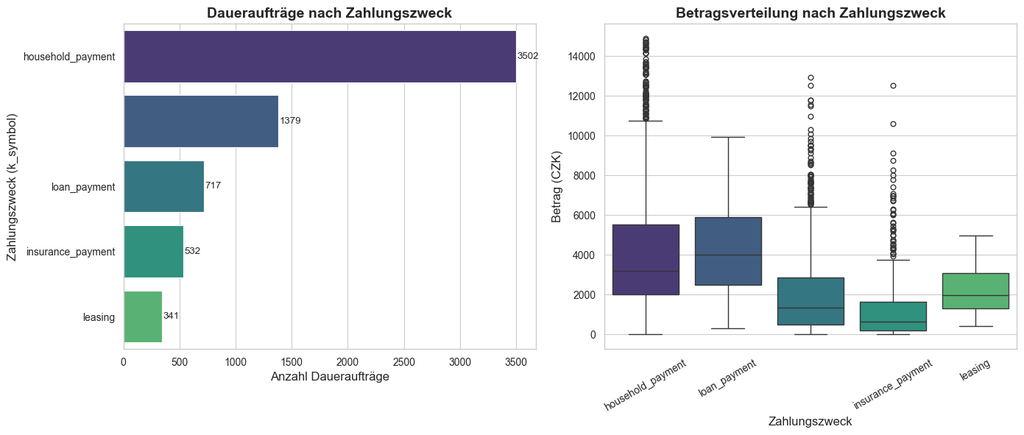

```
Deskriptive Statistik der Dauerauftragsbeträge:
count     6471.0
mean      3280.6
std       2714.5
min          1.0
25%       1241.5
50%       2596.0
75%       4613.5
max      14882.0
Name: amount, dtype: float64
```

```python
fig, axes = plt.subplots(1, 2, figsize=FIG_SIZE_DEFAULT)

# 1. Zahlungszwecke (k_symbol)
order_ksym = order["k_symbol"].value_counts()
sns.barplot(
    x=order_ksym.values,
    y=order_ksym.index,
    hue=order_ksym.index,
    ax=axes[0],
)
axes[0].set_title("Daueraufträge nach Zahlungszweck")
axes[0].set_xlabel("Anzahl Daueraufträge")
axes[0].set_ylabel("Zahlungszweck (k_symbol)")
for i, v in enumerate(order_ksym.values):
    axes[0].text(v + 10, i, str(v), va="center")

# 2. Betragsverteilung nach Zahlungszweck
sns.boxplot(
    data=order,
    x="k_symbol",
    y="amount",
    hue="k_symbol",
    ax=axes[1],
)
axes[1].set_title("Betragsverteilung nach Zahlungszweck")
axes[1].set_xlabel("Zahlungszweck")
axes[1].set_ylabel("Betrag (CZK)")
axes[1].tick_params(axis="x", rotation=30)

plt.tight_layout()
plt.show()

print("Deskriptive Statistik der Dauerauftragsbeträge:")
print(order["amount"].describe().round(1))
```

### 4.7.1 Erkenntnisse

Für das Modell relevant sind das Vorhandensein bestimmter Dauerauftragstypen als binäre Features (`has_household_order`, `has_loan_order`, `has_insurance_order`) sowie die Anzahl und Gesamtsumme aller Daueraufträge als Indikatoren für finanzielle Verpflichtungen.

## 4.8 Zielgruppen-Definition: Kreditkarten-Käufer (Target = 1)

Gemäss Aufgabenstellung werden keine Junior-Karten beworben. Kunden mit `classic` oder `gold` Karte bilden unsere Positivklasse (Target = 1). Wir untersuchen die Verteilung der Kartentypen, die zeitliche Verteilung der Kartenausstellungen und ob sich Gold- und Classic-Karten zeitlich unterschiedlich verteilen.

```
Verteilung der Kartentypen in der gesamten Historie:
type
classic    659
junior     145
gold        88
Name: count, dtype: int64

Anzahl gültiger Kreditkarten (Target = 1 Kandidaten): 747
```

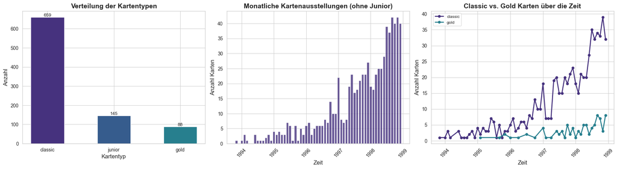

```python
# Verteilung aller Kartentypen
card_distribution = card["type"].value_counts()
print("Verteilung der Kartentypen in der gesamten Historie:")
print(card_distribution)

# Junior-Karten ausschliessen
valid_cards = card[card["type"] != "junior"].copy()
print(f"\nAnzahl gültiger Kreditkarten (Target = 1 Kandidaten): {len(valid_cards)}")

fig, axes = plt.subplots(1, 3, figsize=(18, 5))

# 1. Kartentyp-Verteilung
# Map colors to index
colors_card = {"classic": "C0", "junior": "C1", "gold": "C2"}
card_colors = [colors_card[t] for t in card_distribution.index]

axes[0].bar(
    card_distribution.index, card_distribution.values, color=card_colors, width=0.5
)
axes[0].set_title("Verteilung der Kartentypen")
axes[0].set_xlabel("Kartentyp")
axes[0].set_ylabel("Anzahl")
for i, v in enumerate(card_distribution.values):
    axes[0].text(i, v + 5, str(v), ha="center")

# 2. Zeitliche Verteilung der Kartenausstellungen (nur valid_cards)
# card['issued'] is datetime (from load)
valid_cards["issued_month"] = valid_cards["issued"].dt.to_period("M").dt.to_timestamp()
monthly_cards = valid_cards.groupby("issued_month").size()
axes[1].bar(monthly_cards.index, monthly_cards.values, width=25, alpha=0.8)
axes[1].set_title("Monatliche Kartenausstellungen (ohne Junior)")
axes[1].set_xlabel("Zeit")
axes[1].set_ylabel("Anzahl Karten")
axes[1].tick_params(axis="x", rotation=45)

# 3. Kartentyp-Verteilung über die Zeit (classic vs. gold)
for card_type in ["classic", "gold"]:
    subset = valid_cards[valid_cards["type"] == card_type]
    monthly = subset.groupby("issued_month").size()
    axes[2].plot(
        monthly.index,
        monthly.values,
        marker="o",
        label=card_type,
        color=colors_card[card_type],
        linewidth=2,
    )

axes[2].set_title("Classic vs. Gold Karten über die Zeit")
axes[2].set_xlabel("Zeit")
axes[2].set_ylabel("Anzahl Karten")
axes[2].legend()
axes[2].tick_params(axis="x", rotation=45)

plt.tight_layout()
plt.show()
```

### 4.8.1 Erkenntnisse

Von 892 Karten total sind 145 Junior-Karten (16.2%), die gemäss Aufgabenstellung aus der Zielgruppe ausgeschlossen werden. Die verbleibenden 747 Karten (classic: 659, gold: 88) bilden die Positivklasse (Target = 1).

Gold-Karten sind selten (88, entspricht 11.8% der gültigen Karten) und treten erst ab 1996/97 regelmässig auf. Classic-Karten wachsen ab 1997 stark und erreichen Ende 1998 einen Peak von rund 40 Ausstellungen pro Monat.

## 4.9 Exemplarische Kontoanalyse: Vermögen & Umsatz (Konten 14 und 18)

Gemäss Aufgabenstellung ist die Übersicht der gesamten zeitlichen Entwicklung von Vermögen und Umsatz für Konto Nr. 14 und Nr. 18 pro Monat ein minimales Lieferobjekt. Wir aggregieren die Transaktionen auf Monatsebene:

1. **Vermögen:** Kontostand (`balance`) nach der letzten Transaktion des jeweiligen Monats.
2. **Umsatz:** Totales Transaktionsvolumen (Summe der absoluten Beträge aller Ein- und Ausgänge).

Diese Analyse dient gleichzeitig als Proof-of-Concept für das spätere 12-Monate-Rollup.

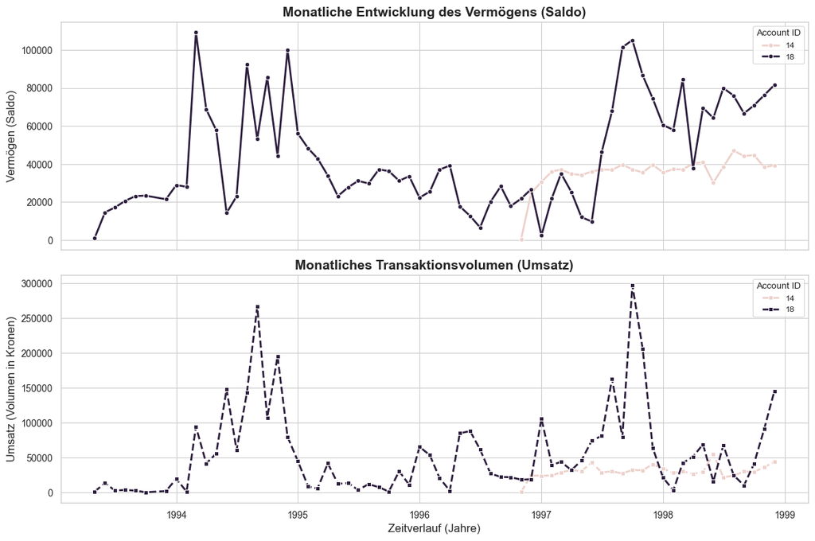

```python
# 1. Daten für Konto 14 und 18 filtern und zeitlich sortieren
acc_subset = trans[trans["account_id"].isin([14, 18])].copy()
acc_subset = acc_subset.sort_values(by=["account_id", "date", "trans_id"])

# 2. Jahr-Monat Periode extrahieren
# trans["date"] is datetime
acc_subset["year_month"] = acc_subset["date"].dt.to_period("M")


# 3. Aggregation auf Monatsebene
# Umsatz = Summe aller absoluten Beträge im Monat (Volumen um Aktivität zu messen)
# Vermögen = Der Kontostand nach der LETZTEN Transaktion im Monat
def sum_abs(x):
    return x.abs().sum()


monats_agg = (
    acc_subset.groupby(["account_id", "year_month"])
    .agg(umsatz=("amount", sum_abs), vermoegen=("balance", "last"))
    .reset_index()
)

# Zurück in Datetime konvertieren, damit Matplotlib die X-Achse schön rendert
monats_agg["year_month"] = monats_agg["year_month"].dt.to_timestamp()

# 4. Visualisierung
fig, axes = plt.subplots(2, 1, figsize=(12, 8), sharex=True)

# Subplot 1: Vermögensentwicklung
sns.lineplot(
    data=monats_agg,
    x="year_month",
    y="vermoegen",
    hue="account_id",
    ax=axes[0],
    marker="o",
    linewidth=2,
)
axes[0].set_title("Monatliche Entwicklung des Vermögens (Saldo)")
axes[0].set_ylabel("Vermögen (Saldo)")
axes[0].legend(title="Account ID")

# Subplot 2: Umsatzentwicklung
sns.lineplot(
    data=monats_agg,
    x="year_month",
    y="umsatz",
    hue="account_id",
    ax=axes[1],
    marker="s",
    linestyle="--",
    linewidth=2,
)
axes[1].set_title("Monatliches Transaktionsvolumen (Umsatz)")
axes[1].set_ylabel("Umsatz (Volumen in Kronen)")
axes[1].set_xlabel("Zeitverlauf (Jahre)")
axes[1].legend(title="Account ID")

plt.tight_layout()
plt.show()
```

### 4.9.1 Erkenntnisse

Die beiden Konten zeigen grundlegend unterschiedliche Verhaltensmuster. Konto 18 ist hochvolatil mit unregelmässigen Umsatzspikes von bis zu 300000 CZK pro Monat und entsprechend starken Schwankungen im Saldo (Bereich ca. 1000 bis 107000 CZK). Konto 14 erscheint erst ab 1997 (spätere Kontoeröffnung), hat einen moderaten und gleichmässigeren Umsatz unter 50000 CZK pro Monat und einen stabilen Saldo im Bereich 25000 bis 45000 CZK.

Diese Beispiele verdeutlichen die Notwendigkeit von Rollup-Features: Der letzte Kontostand (`balance_last`) und der Gesamtumsatz (`turnover`) über ein 12-Monats-Fenster aggregieren diese volatilen Zeitreihen zu einer einzelnen Zahl pro Konto. Statistische Kennzahlen wie Standardabweichung, Median und Trend ergänzen dabei das Bild und sind robuster gegenüber einzelnen Ausreissern.

## 4.10 Zeitliche Analyse: Kontoeröffnung bis Kartenkauf

Um eine faire Strategie für die Zuweisung von Vergleichszeitpunkten an Nicht-Kartenbesitzer zu entwickeln, untersuchen wir zunächst, wie viele Monate nach Kontoeröffnung typischerweise eine Kreditkarte ausgestellt wird. Diese Verteilung bildet die Grundlage für die spätere Pseudo-Event-Zuweisung im Studiendesign.

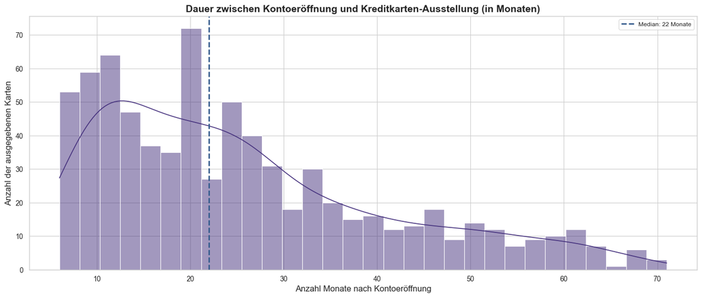

```
Zusammenfassende Statistiken (Monate bis zum Kartenkauf):
count    747.0
mean      25.6
std       15.4
min        6.0
25%       13.0
50%       22.0
75%       34.0
max       71.0
Name: months_to_card, dtype: float64
```

```python
# Zusammenführen von Karte -> Disp -> Account um das Konto-Eröffnungsdatum zu erhalten
card_account_map = pd.merge(
    valid_cards, disp[["disp_id", "account_id"]], on="disp_id", how="inner"
)
card_account_map = pd.merge(
    card_account_map, account[["account_id", "date"]], on="account_id", how="inner"
)
card_account_map.rename(columns={"date": "account_creation_date"}, inplace=True)

# Berechnung: Wie viele Monate vom Konto-Eröffnungsdatum bis zum Ausstellungsdatum der Karte?
# Both date columns are datetime. using .dt.year/month works.
card_account_map["months_to_card"] = (
    card_account_map["issued"].dt.year
    - card_account_map["account_creation_date"].dt.year
) * 12 + (
    card_account_map["issued"].dt.month
    - card_account_map["account_creation_date"].dt.month
)

# Plotting der Verteilung
plt.figure(figsize=FIG_SIZE_DEFAULT)
sns.histplot(card_account_map["months_to_card"], bins=30, kde=True)
plt.title("Dauer zwischen Kontoeröffnung und Kreditkarten-Ausstellung (in Monaten)")
plt.xlabel("Anzahl Monate nach Kontoeröffnung")
plt.ylabel("Anzahl der ausgegebenen Karten")
plt.axvline(
    card_account_map["months_to_card"].median(),
    color="C1",
    linestyle="dashed",
    linewidth=2,
    label=f"Median: {int(card_account_map['months_to_card'].median())} Monate",
)
plt.legend()
plt.tight_layout()
plt.show()

print("Zusammenfassende Statistiken (Monate bis zum Kartenkauf):")
print(card_account_map["months_to_card"].describe().round(1))
```

### 4.10.1 Erkenntnisse

Die Verteilung ist rechtsschief: Die Mehrheit der Kartenausstellungen erfolgt innerhalb der ersten 2 Jahre nach Kontoeröffnung, mit einem Median von 22 Monaten und einem Modus um 20 Monate. Ein langer rechter Schwanz erstreckt sich bis 71 Monate.

Das Minimum von 6 Monaten zeigt, dass einzelne Karten sehr früh ausgestellt wurden. Der 25%-Quantil liegt bei 13 Monaten, was dem Mindest-Rollup-Constraint (12M Rollup + 1M Lag = 13M) entspricht. Karten, die innerhalb der ersten 13 Monate ausgestellt wurden, können kein vollständiges Rollup-Fenster vorweisen und werden im Studiendesign ausgeschlossen.

Diese Verteilung bildet die empirische Grundlage für die Pseudo-Event-Zuweisung an Nicht-Kartenbesitzer. Sie wird ausschliesslich aus Train-Card-Holders berechnet, um Data Leakage zu verhindern.

## 4.11 Erster Vergleich: Kartenbesitzer vs. Nicht-Kartenbesitzer

Bevor wir das Studiendesign und Feature Engineering angehen, werfen wir einen ersten deskriptiven Blick auf die Unterschiede zwischen Personen, die eine Kreditkarte erhalten haben (Target=1, ohne Junior) und solchen ohne (Target=0). Dieser Vergleich erfolgt noch ohne Rollup-Bereinigung und dient der Hypothesenbildung.

```
Target-Verteilung:
  Target=0 (kein Card): 4622
  Target=1 (classic/gold): 747
  Anteil Target=1: 13.9%
```

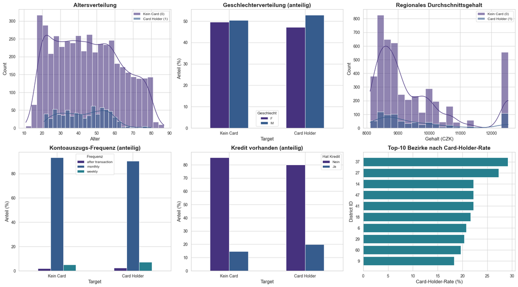

```
Deskriptiver Vergleich (Mittelwerte):
                 alter_mean  anteil_frauen  gehalt_mean  anteil_kredit
Kein Card (0)         45.13          49.61      9495.56           0.15
Card Holder (1)       42.96          47.12      9604.78           0.20
```

```python
# Target-Label zuweisen: card -> disp -> client
# Kunden mit valid_card (classic/gold) = Target 1, alle anderen = Target 0
card_holder_disp_ids = set(valid_cards["disp_id"])
client_with_disp = pd.merge(
    client, disp[["disp_id", "client_id", "account_id"]], on="client_id", how="left"
)
client_with_disp["target"] = (
    client_with_disp["disp_id"].isin(card_holder_disp_ids).astype(int)
)

# Zusätzlich: hat der Kunde einen Kredit?
loan_accounts = set(loan["account_id"])
client_with_disp["has_loan"] = (
    client_with_disp["account_id"].isin(loan_accounts).astype(int)
)

# Kontofrequenz hinzufügen
client_with_disp = pd.merge(
    client_with_disp,
    account[["account_id", "frequency"]],
    on="account_id",
    how="left",
)

# Bezirksgehalt hinzufügen
client_with_disp = pd.merge(
    client_with_disp,
    district[["district_id", "A11"]].rename(columns={"A11": "avg_salary"}),
    on="district_id",
    how="left",
)

target_counts = client_with_disp["target"].value_counts().sort_index()
print(f"Target-Verteilung:\n  Target=0 (kein Card): {target_counts.get(0, 0)}")
print(f"  Target=1 (classic/gold): {target_counts.get(1, 0)}")
print(
    f"  Anteil Target=1: {target_counts.get(1, 0) / len(client_with_disp) * 100:.1f}%"
)

fig, axes = plt.subplots(2, 3, figsize=(18, 10))
labels = {0: "Kein Card (0)", 1: "Card Holder (1)"}
target_colors = {0: "C0", 1: "C1"}

# 1. Altersverteilung
for t in [0, 1]:
    subset = client_with_disp[client_with_disp["target"] == t]
    sns.histplot(
        subset["age"],
        bins=25,
        alpha=0.6,
        label=labels[t],
        ax=axes[0, 0],
        kde=True,
        color=target_colors[t],
    )
axes[0, 0].set_title("Altersverteilung")
axes[0, 0].set_xlabel("Alter")
axes[0, 0].legend()

# 2. Geschlechterverteilung
gender_target = (
    client_with_disp.groupby(["target", "gender"]).size().unstack(fill_value=0)
)
gender_target_pct = gender_target.div(gender_target.sum(axis=1), axis=0) * 100
gender_target_pct.plot(kind="bar", ax=axes[0, 1], color=["C0", "C1"])
axes[0, 1].set_title("Geschlechterverteilung (anteilig)")
axes[0, 1].set_xlabel("Target")
axes[0, 1].set_ylabel("Anteil (%)")
axes[0, 1].set_xticklabels(["Kein Card", "Card Holder"], rotation=0)
axes[0, 1].legend(title="Geschlecht")

# 3. Durchschnittsgehalt der Region
for t in [0, 1]:
    subset = client_with_disp[client_with_disp["target"] == t]
    sns.histplot(
        subset["avg_salary"],
        bins=20,
        alpha=0.6,
        label=labels[t],
        ax=axes[0, 2],
        kde=True,
        color=target_colors[t],
    )
axes[0, 2].set_title("Regionales Durchschnittsgehalt")
axes[0, 2].set_xlabel("Gehalt (CZK)")
axes[0, 2].legend()

# 4. Kontofrequenz
freq_target = (
    client_with_disp.groupby(["target", "frequency"]).size().unstack(fill_value=0)
)
freq_target_pct = freq_target.div(freq_target.sum(axis=1), axis=0) * 100
freq_target_pct.plot(kind="bar", ax=axes[1, 0])
axes[1, 0].set_title("Kontoauszugs-Frequenz (anteilig)")
axes[1, 0].set_xlabel("Target")
axes[1, 0].set_ylabel("Anteil (%)")
axes[1, 0].set_xticklabels(["Kein Card", "Card Holder"], rotation=0)
axes[1, 0].legend(title="Frequenz")

# 5. Has Loan
loan_target = (
    client_with_disp.groupby(["target", "has_loan"]).size().unstack(fill_value=0)
)
loan_target_pct = loan_target.div(loan_target.sum(axis=1), axis=0) * 100
loan_target_pct.plot(kind="bar", ax=axes[1, 1], color=["C0", "C1"])
axes[1, 1].set_title("Kredit vorhanden (anteilig)")
axes[1, 1].set_xlabel("Target")
axes[1, 1].set_ylabel("Anteil (%)")
axes[1, 1].set_xticklabels(["Kein Card", "Card Holder"], rotation=0)
axes[1, 1].legend(title="Hat Kredit", labels=["Nein", "Ja"])

# 6. Top-Bezirke nach Card-Holder-Rate
district_target = client_with_disp.groupby("district_id").agg(
    total=("target", "count"), card_holders=("target", "sum")
)
district_target["card_rate"] = (
    district_target["card_holders"] / district_target["total"] * 100
)
# Nur Bezirke mit mindestens 20 Kunden für stabile Raten
district_target_stable = district_target[district_target["total"] >= 20].sort_values(
    "card_rate", ascending=False
)
top_districts = district_target_stable.head(10)
axes[1, 2].barh(top_districts.index.astype(str), top_districts["card_rate"], color="C2")
axes[1, 2].set_title("Top-10 Bezirke nach Card-Holder-Rate")
axes[1, 2].set_xlabel("Card-Holder-Rate (%)")
axes[1, 2].set_ylabel("District ID")
axes[1, 2].invert_yaxis()

plt.tight_layout()
plt.show()

# Zusammenfassung
print("\nDeskriptiver Vergleich (Mittelwerte):")
comparison = (
    client_with_disp.groupby("target")
    .agg(
        alter_mean=("age", "mean"),
        anteil_frauen=("gender", lambda x: (x == "F").mean() * 100),
        gehalt_mean=("avg_salary", "mean"),
        anteil_kredit=("has_loan", "mean"),
    )
    .round(2)
)
comparison.index = ["Kein Card (0)", "Card Holder (1)"]
print(comparison.to_string())
```

### 4.11.1 Erkenntnisse

Die Zielvariable ist moderat unbalanciert: 13.9% Kartenbesitzer (747) gegenüber 86.1% Nicht-Kartenbesitzer (4622). Dieser Vergleich erfolgt noch vor dem Rollup-Filter und ohne Studiendesign-Bereinigung.

Die Unterschiede zwischen den Gruppen auf den Baseline-Features sind insgesamt gering:

- **Alter:** Kartenbesitzer sind im Schnitt etwas jünger (Mittelwert 43.0 vs. 45.1 Jahre). Der Unterschied ist statistisch vorhanden, aber klein.
- **Geschlecht:** Kartenbesitzer sind leicht häufiger männlich (53% vs. 50%). Kein starkes Signal.
- **Durchschnittsgehalt:** Marginaler Unterschied (9605 vs. 9496 CZK). Beide Gruppen ähnlich verteilt.
- **Kredit vorhanden:** Der deutlichste Unterschied: 20% der Kartenbesitzer haben einen Kredit gegenüber 15% der Nicht-Kartenbesitzer. Kartenbesitzer nutzen tendenziell mehr Finanzprodukte.
- **Kontoauszugs-Frequenz:** Nahezu identisch in beiden Gruppen, kein Signal.

Die schwache Trennung auf den Basis-Features zeigt, dass diese allein nicht ausreichen für ein starkes Modell. Transaktionsbasierte Behavioral-Features aus dem Rollup-Fenster werden für die eigentliche Trennleistung entscheidend sein.

```python
# === Studiendesign: Konstanten ===
# (Definiert in den globalen Konstanten am Anfang des Notebooks)

print("Studiendesign-Konstanten definiert:")
print(f"  Rollup-Fenster:    {ROLLUP_MONTHS} Monate")
print(f"  Lag-Monat:         {LAG_MONTHS} Monat")
print(f"  Gesamt-Historie:   {TOTAL_HISTORY_MONTHS} Monate")
print(f"  Junior-Cutoff:     {JUNIOR_AGE_CUTOFF} Jahre")
print(f"  Split-Ratios:      Train={TRAIN_RATIO}, Test={TEST_RATIO}")
```

```
Studiendesign-Konstanten definiert:
  Rollup-Fenster:    12 Monate
  Lag-Monat:         1 Monat
  Gesamt-Historie:   13 Monate
  Junior-Cutoff:     21 Jahre
  Split-Ratios:      Train=0.8, Test=0.2
```

# 5 Studiendesign: Zeitliche Synchronisierung

Kartenbesitzer haben ein natürliches Ereignisdatum: den Tag der Kartenausstellung. Nicht-Kartenbesitzer hingegen haben keinen solchen Ankerpunkt. Wenn wir für die Kontrollgruppe einen willkürlichen Vergleichszeitpunkt wählen (z.B. das Ende der Datenhistorie oder ein zufälliges Datum), entsteht ein sogenannter **Immortal Time Bias** — die Kontrollgruppe hätte systematisch längere Kontohistorien und damit ein anderes Transaktionsmuster, das nicht auf echten Verhaltensunterschieden basiert, sondern auf dem zeitlichen Artefakt.

Aus der pharmakoepidemiologischen Literatur zu *New-User Designs* (Pottegård 2022, Her 2024, Suissa 2008) wissen wir, dass der **Zeitpunkt Null** (*Time Zero*) zwischen Behandlungs- und Kontrollgruppe synchronisiert werden muss, um faire Vergleiche zu ermöglichen. Wir übertragen dieses Prinzip auf unser Affinitätsmodell: Jeder Nicht-Kartenbesitzer erhält ein **Pseudo-Ereignisdatum**, das so gewählt wird, dass die Verteilung der Kontoalter zum Ereigniszeitpunkt zwischen beiden Gruppen vergleichbar ist.

### 5.0.1 Ausschluss-Kriterien (vor dem Rollup)

1. **DISPONENTen:** Nur Konto-Inhaber (OWNER) werden berücksichtigt.
2. **Junior-Alter:** Kunden unter 21 Jahren zum Ereigniszeitpunkt werden ausgeschlossen, da Junior-Karten nicht im Angebot sind — datenbasierte Begründung folgt im nächsten Abschnitt.
3. **Unzureichende Historie:** Konten mit weniger als 13 Monaten Transaktionshistorie vor dem Ereignis (12 Monate Rollup + 1 Monat Lag).

### 5.0.2 Lag-Monat

Zwischen dem Ende des Rollup-Fensters und dem Ereignisdatum liegt ein **1-Monats-Buffer** (Lag). Dieser verhindert, dass Transaktionen aus dem Karten-Antragsmonat (z.B. erhöhte Aktivität durch den Antragsprozess) in die Features einfliessen und Target Leakage verursachen. Das Fenster lautet damit: `[rollup_start ... rollup_end] [1M Lag] [event_date]`.

### 5.0.3 Datenbasierte Validierung der Altersschwelle

Die Eligibility-Regel “Alter >= 21” soll Junior-Karten-Kandidaten ausschliessen, da klassische/goldene Kreditkarten erst ab Volljährigkeit + Boniprüfung vergeben werden. Bevor wir den Filter anwenden, prüfen wir aus den Daten, **wie jung** echte Card-Holder zum Kaufzeitpunkt tatsächlich waren und wie viele Kunden im kritischen Altersband [18, 21) liegen.

```python
# === Datenbasierte Validierung der Altersschwelle (vor Eligibility-Filter) ===

# Minimal-Build von owner_clients für die Validierung (analoge Logik wie unten)
_owner_disps_val = disp[disp["type"] == "OWNER"].copy()
_owner_clients_val = _owner_disps_val.merge(
    client[["client_id", "birth_date"]], on="client_id", how="left"
).merge(
    card_account_map[["account_id", "issued"]].rename(
        columns={"issued": "card_issued"}
    ),
    on="account_id",
    how="left",
)
_owner_clients_val["is_card_holder"] = _owner_clients_val["account_id"].isin(
    set(card_account_map["account_id"])
)
# Card-Holder: Alter bei Kartenausstellung; Non-Card: Alter zum Ende der Datenhistorie
_owner_clients_val["event_ref_date"] = _owner_clients_val["card_issued"].fillna(
    max_global_date
)
_owner_clients_val["age_at_event"] = (
    _owner_clients_val["event_ref_date"] - _owner_clients_val["birth_date"]
).dt.days / 365.25

# 1. Jüngstes Alter zum Ereigniszeitpunkt je Gruppe
print("=== Jüngstes Alter zum Ereigniszeitpunkt ===")
_min_age_card = _owner_clients_val.loc[
    _owner_clients_val["is_card_holder"], "age_at_event"
].min()
_min_age_non_card = _owner_clients_val.loc[
    ~_owner_clients_val["is_card_holder"], "age_at_event"
].min()
print(f"  Card-Holder      : {_min_age_card:.2f} Jahre")
print(f"  Nicht-Card-Holder: {_min_age_non_card:.2f} Jahre")

# 2. Quantile des Alters zum Ereigniszeitpunkt
print("\n=== Quantile age_at_event (Jahre) ===")
_quantiles = [0.01, 0.05, 0.25, 0.50, 0.75, 0.95]
_q_df = (
    _owner_clients_val.groupby("is_card_holder")["age_at_event"]
    .quantile(_quantiles)
    .unstack(level=1)
    .round(2)
)
_q_df.index = _q_df.index.map({True: "Card-Holder", False: "Nicht-Card-Holder"})
_q_df.columns = [f"q{int(q * 100)}" for q in _quantiles]
print(_q_df.to_string())

# 3. Anzahl Kunden im Altersband [18, 21) und unter 18
print("\n=== Verteilung im kritischen Altersband ===")
_under_18 = _owner_clients_val["age_at_event"] < 18
_band_18_21 = (_owner_clients_val["age_at_event"] >= 18) & (
    _owner_clients_val["age_at_event"] < 21
)
for label, mask in [("< 18 Jahre", _under_18), ("[18, 21) Jahre", _band_18_21)]:
    n_total = mask.sum()
    n_card = (mask & _owner_clients_val["is_card_holder"]).sum()
    n_non_card = (mask & ~_owner_clients_val["is_card_holder"]).sum()
    print(
        f"  {label:18s}: total={n_total:4d}  "
        f"davon Card-Holder={n_card:3d}, Nicht-Card-Holder={n_non_card:4d}"
    )

# Aufräumen der temporären Variablen
del _owner_disps_val, _owner_clients_val, _q_df
```

```
=== Jüngstes Alter zum Ereigniszeitpunkt ===
  Card-Holder      : 20.28 Jahre
  Nicht-Card-Holder: 16.05 Jahre

=== Quantile age_at_event (Jahre) ===
                      q1     q5    q25    q50    q75    q95
is_card_holder
Nicht-Card-Holder  17.43  19.56  29.13  43.79  58.53  75.95
Card-Holder        20.81  22.60  31.28  42.95  52.99  60.50

=== Verteilung im kritischen Altersband ===
  < 18 Jahre        : total=  57  davon Card-Holder=  0, Nicht-Card-Holder=  57
  [18, 21) Jahre    : total= 298  davon Card-Holder= 11, Nicht-Card-Holder= 287
```

Der jüngste Card-Holder war 20.28 Jahre alt. Im Band [18, 21) gibt es 11 echte Card-Holder. Das sind Ausnahmen (11 von 747, ~1.5%). Die Schwelle 21 ist daher keine datenbasiert exakte Grenze, sondern eine pragmatische Abgrenzung: Sie schliesst eine Altersgruppe aus, in der Karten sehr selten vergeben wurden, und deckt sich mit dem Mindestalter für Junior-Card-Holder aus der Produktbeschreibung. “Konservativ” trifft zu, aber nicht im Sinne von “null Ausnahmen”, sondern im Sinne von “auf der sicheren Seite”.

```python
# === Eligibility Filtering: OWNERs only, junior-age exclusion ===

# 1. Nur OWNER-Dispositionen (DISPONENTen ausschliessen)
owner_disps = disp[disp["type"] == "OWNER"].copy()
print(f"Dispositionen total:   {len(disp)}")
print(f"  davon OWNER:         {len(owner_disps)}")
print(f"  davon DISPONENT:     {len(disp) - len(owner_disps)}")

# 2. Merge mit Client-Daten für Geburtsdatum
owner_clients = owner_disps.merge(
    client[["client_id", "birth_date"]], on="client_id", how="left"
)

# 3. Card-Holder identifizieren und Ausstellungsdatum hinzufügen
card_account_ids = set(card_account_map["account_id"])
owner_clients = owner_clients.merge(
    card_account_map[["account_id", "issued"]].rename(
        columns={"issued": "card_issued"}
    ),
    on="account_id",
    how="left",
)
owner_clients["is_card_holder"] = owner_clients["account_id"].isin(card_account_ids)

# 4. Alter zum Ereigniszeitpunkt berechnen
# Card-Holder: Alter bei Kartenausstellung
# Nicht-Card-Holder: Alter am Ende der Datenhistorie (konservative Schätzung)
owner_clients["event_ref_date"] = owner_clients["card_issued"].fillna(max_global_date)
owner_clients["age_at_event"] = (
    owner_clients["event_ref_date"] - owner_clients["birth_date"]
).dt.days / 365.25

# 5. Junior-Alter ausschliessen
junior_mask = owner_clients["age_at_event"] < JUNIOR_AGE_CUTOFF
n_junior_excluded = junior_mask.sum()
n_junior_card = (junior_mask & owner_clients["is_card_holder"]).sum()
n_junior_non_card = (junior_mask & ~owner_clients["is_card_holder"]).sum()

eligible = owner_clients[~junior_mask].copy()
eligible_account_ids: set[int] = set(eligible["account_id"])

print(f"\n--- Alters-Ausschluss (< {JUNIOR_AGE_CUTOFF} Jahre) ---")
print(f"  Ausgeschlossen total:     {n_junior_excluded}")
print(f"    davon Card-Holder:      {n_junior_card}")
print(f"    davon Nicht-Card-Holder: {n_junior_non_card}")
print(f"\n  Eligible Accounts:        {len(eligible_account_ids)}")

# Validierung: Alle valid cards gehören zu OWNERs
card_disp_types = valid_cards.merge(
    disp[["disp_id", "type"]].rename(columns={"type": "disp_type"}), on="disp_id"
)
assert (
    card_disp_types["disp_type"] == "OWNER"
).all(), "Nicht alle Karten gehören OWNERs!"
print(f"\n  Validierung: Alle {len(valid_cards)} valid cards gehören zu OWNERs ✓")
```

```
Dispositionen total:   5369
  davon OWNER:         4500
  davon DISPONENT:     869

--- Alters-Ausschluss (< 21 Jahre) ---
  Ausgeschlossen total:     355
    davon Card-Holder:      11
    davon Nicht-Card-Holder: 344

  Eligible Accounts:        4145

  Validierung: Alle 747 valid cards gehören zu OWNERs ✓
```

### 5.0.4 Interpretation der Eligibility-Filterung

Die Validierung bestätigt: Alle 747 gültigen Karten (classic + gold) gehören zu OWNER-Dispositionen. Die verbleibenden Accounts bilden die **eligible population** für das Studiendesign.

```python
# === Studientabelle der Kartenbesitzer (mit Lag-Monat) ===

# Erste Transaktion pro Konto (= frühester möglicher Rollup-Start)
first_trans_per_account = (
    trans.groupby("account_id")["date"].min().rename("first_trans_date")
)

# Nur eligible card holders
card_study = card_account_map[
    card_account_map["account_id"].isin(eligible_account_ids)
][["account_id", "account_creation_date", "issued", "months_to_card"]].copy()
card_study.rename(
    columns={"issued": "event_date", "months_to_card": "months_to_event"}, inplace=True
)
card_study["target"] = 1

# Erste Transaktion hinzufügen
card_study = card_study.merge(first_trans_per_account, on="account_id", how="left")

# Rollup mit Lag: rollup_end = event - 1 Monat, rollup_start = event - 13 Monate
# Robuste Monatsarithmetik via .to_period("M")
card_study["rollup_end"] = card_study["event_date"].apply(
    lambda d: (d.to_period("M") - LAG_MONTHS).to_timestamp()
)
card_study["rollup_start"] = card_study["event_date"].apply(
    lambda d: (d.to_period("M") - TOTAL_HISTORY_MONTHS).to_timestamp()
)

# Prüfung: Hat das Konto genügend Historie für den vollständigen Rollup?
card_study["has_complete_rollup"] = (
    card_study["rollup_start"] >= card_study["first_trans_date"]
)

print(f"=== Kartenbesitzer: Rollup-Vollständigkeit (inkl. {LAG_MONTHS}M Lag) ===")
print(f"  Eligible Card-Holder:             {len(card_study)}")
print(
    f"  Mit vollständigem {TOTAL_HISTORY_MONTHS}M-Rollup:     {card_study['has_complete_rollup'].sum()}"
)
print(
    f"  Ausgeschlossen (kurze Historie):  {(~card_study['has_complete_rollup']).sum()}"
)

# Nur Konten mit vollständigem Rollup behalten
card_study_valid = card_study[card_study["has_complete_rollup"]].copy()
card_study_valid = card_study_valid[
    [
        "account_id",
        "account_creation_date",
        "event_date",
        "rollup_start",
        "rollup_end",
        "months_to_event",
        "target",
    ]
]

print(f"\n  Finale Studiengruppe Target=1: {len(card_study_valid)} Konten")
```

```
=== Kartenbesitzer: Rollup-Vollständigkeit (inkl. 1M Lag) ===
  Eligible Card-Holder:             736
  Mit vollständigem 13M-Rollup:     540
  Ausgeschlossen (kurze Historie):  196

  Finale Studiengruppe Target=1: 540 Konten
```

## 5.1 Strategie: Kontrollierte Tenure-Matched Zufallszuweisung

Um Nicht-Kartenbesitzern ein faires Pseudo-Ereignisdatum zuzuweisen, verwenden wir die **empirische Verteilung der Kontoalter zum Kartenkaufzeitpunkt** — aber ausschliesslich aus dem **Trainingsset** — als Vorlage. Damit wird verhindert, dass Informationen aus dem Testset in die Pseudo-Event-Zuweisung einfliessen (Data Leakage).

**Ablauf:**

1. **Stratifizierter 80/20-Split** aller eligible Accounts (nach Target) → Train / Test
2. Empirische `months_to_event`-Verteilung wird **nur aus Train-Card-Holders** berechnet
3. Pseudo-Events werden mit dieser Train-Verteilung für **alle** Non-Card-Accounts zugewiesen
4. Hyperparameter-Tuning und Modellselektion erfolgen via **k-Fold Cross-Validation** auf dem Trainingsset

**Algorithmus für jedes Nicht-Karten-Konto:**

1. Berechne den **machbaren Bereich** von `months_to_event`: Minimum = genügend Monate für 12M Rollup + 1M Lag; Maximum = begrenzt durch das Ende der Transaktionsdaten.
2. **Filtere** die empirische Train-Verteilung auf diesen machbaren Bereich.
3. **Ziehe** einen Wert → `event_date = account_creation_date + gezogene Monate`.
4. Berechne `rollup_end = event_date - 1 Monat` und `rollup_start = rollup_end - 12 Monate`.

**Warum Tenure-Matching statt Kalenderzeit?** Die Kartenausstellungen konzentrieren sich auf 1997–1998. Ein reines Kalenderzeit-Matching würde Nicht-Kartenbesitzern, deren Konten 1993–1994 eröffnet wurden, künstlich lange Historien zuordnen. Das Tenure-Matching stellt sicher, dass das **Kontoalter zum Ereigniszeitpunkt** zwischen beiden Gruppen verteilungsgleich ist.

**Warum kein Validierungsset?** Da Hyperparameter-Tuning und Modellselektion über **stratifizierte k-Fold Cross-Validation** auf dem Trainingsset erfolgen, ist ein separates Validierungsset überflüssig. Der 80/20-Split maximiert die verfügbare Trainingsmenge — wichtig bei einem kleinen Datensatz mit moderatem Klassenungleichgewicht.

```python
# === Stratifizierter Train/Test Split (VOR Pseudo-Event-Zuweisung) ===

# Alle eligible Accounts mit Target-Label
eligible_accounts = pd.DataFrame({"account_id": list(eligible_account_ids)})
eligible_accounts["target"] = (
    eligible_accounts["account_id"].isin(card_account_ids).astype(int)
)

# Single split: Train (80%) vs Test (20%), stratifiziert nach Target
train_accs, test_accs = train_test_split(
    eligible_accounts,
    test_size=TEST_RATIO,
    stratify=eligible_accounts["target"],
    random_state=RANDOM_STATE,
)

# Split-Map: account_id -> "train"/"test"
split_map: dict[int, str] = {}
for acc_id in train_accs["account_id"]:
    split_map[acc_id] = "train"
for acc_id in test_accs["account_id"]:
    split_map[acc_id] = "test"

# Empirische months_to_event Verteilung NUR aus Train-Card-Holders
train_card_ids = set(train_accs[train_accs["target"] == 1]["account_id"])
empirical_months = card_study_valid[
    card_study_valid["account_id"].isin(train_card_ids)
]["months_to_event"]

print("=== Stratifizierter Split (80/20) ===")
for split_name, split_df in [
    ("Train", train_accs),
    ("Test", test_accs),
]:
    n = len(split_df)
    n1 = split_df["target"].sum()
    print(f"  {split_name:5s}: {n:4d} Accounts  (Target=1: {n1:3d}, {n1/n*100:5.1f}%)")
print(f"\n  Empirische Verteilung aus {len(empirical_months)} Train-Card-Holders")
```

```
=== Stratifizierter Split (80/20) ===
  Train: 3316 Accounts  (Target=1: 589,  17.8%)
  Test :  829 Accounts  (Target=1: 147,  17.7%)

  Empirische Verteilung aus 431 Train-Card-Holders
```

```python
# === Pseudo-Ereignisdaten für Nicht-Kartenbesitzer (Train-only Distribution) ===
# assign_pseudo_event_dates ist in src/data.py definiert (DRY-Prinzip).

# Eligible Non-Card Account IDs
eligible_non_card_ids = eligible_account_ids - card_account_ids

non_card_study = assign_pseudo_event_dates(
    account_df=account[["account_id", "date"]],
    eligible_non_card_ids=eligible_non_card_ids,
    empirical_months=empirical_months,
    max_data_date=max_global_date,
    first_trans=first_trans_per_account.reset_index(),
)

print(f"\nPseudo-Ereignisdaten zugewiesen: {len(non_card_study)} Nicht-Karten-Konten")
print(
    f"Alle months_to_event >= {TOTAL_HISTORY_MONTHS}: {(non_card_study['months_to_event'] >= TOTAL_HISTORY_MONTHS).all()}"
)
non_card_study.head()
```

```
  Ausgeschlossen (unzureichende Historie): 56 Konten

Pseudo-Ereignisdaten zugewiesen: 3353 Nicht-Karten-Konten
Alle months_to_event >= 13: True
```

|  | account_id | account_creation_date | event_date | rollup_start | rollup_end | months_to_event | target |
| --- | --- | --- | --- | --- | --- | --- | --- |
| 0 | 576 | 1993-01-01 | 1995-09-01 | 1994-08-01 | 1995-08-01 | 32 | 0 |
| 1 | 3818 | 1993-01-01 | 1998-02-01 | 1997-01-01 | 1998-01-01 | 61 | 0 |
| 2 | 704 | 1993-01-01 | 1997-08-01 | 1996-07-01 | 1997-07-01 | 55 | 0 |
| 3 | 2378 | 1993-01-01 | 1995-04-01 | 1994-03-01 | 1995-03-01 | 27 | 0 |
| 4 | 2632 | 1993-01-02 | 1994-08-02 | 1993-07-01 | 1994-07-01 | 19 | 0 |

```python
# === Studienpopulation zusammenführen mit Split-Labels ===

study_table = pd.concat([card_study_valid, non_card_study], ignore_index=True)

# Datetime-Typen sicherstellen
study_table["event_date"] = pd.to_datetime(study_table["event_date"])
study_table["rollup_start"] = pd.to_datetime(study_table["rollup_start"])
study_table["rollup_end"] = pd.to_datetime(study_table["rollup_end"])

# Split-Label zuweisen
study_table["split"] = study_table["account_id"].map(split_map)

print("=" * 60)
print("STUDIENPOPULATION: Kreditkarten-Käufer vs. Nicht-Käufer")
print(f"  mit {ROLLUP_MONTHS}M Rollup + {LAG_MONTHS}M Lag, stratifiziertem Split")
print("=" * 60)

# Crosstab: Target × Split
ct = pd.crosstab(
    study_table["target"].map({0: "Target=0", 1: "Target=1"}),
    study_table["split"],
    margins=True,
)
print(f"\n{ct.to_string()}")

# Prozentuale Verteilung pro Split
print("\nTarget=1 Anteil pro Split:")
for split_name in ["train", "test"]:
    sub = study_table[study_table["split"] == split_name]
    n1 = sub["target"].sum()
    print(f"  {split_name:5s}: {n1}/{len(sub)} = {n1/len(sub)*100:.1f}%")
```

```
============================================================
STUDIENPOPULATION: Kreditkarten-Käufer vs. Nicht-Käufer
  mit 12M Rollup + 1M Lag, stratifiziertem Split
============================================================

split     test  train   All
target
Target=0   673   2680  3353
Target=1   109    431   540
All        782   3111  3893

Target=1 Anteil pro Split:
  train: 431/3111 = 13.9%
  test : 109/782 = 13.9%
```

### 5.1.1 Interpretation der Studienpopulation

Von den ursprünglich 747 Kartenbesitzern (classic + gold) wurden zunächst DISPONENTen und Kunden unter 21 Jahren ausgeschlossen. Von den verbleibenden eligible Card-Holders wurden jene entfernt, deren Karte innerhalb der ersten 13 Monate nach Kontoeröffnung ausgestellt wurde — für diese existiert keine vollständige Rollup-Historie (12M + 1M Lag).

**Stratifizierter Split:** Der 80/20-Split erfolgt **vor** der Pseudo-Event-Zuweisung. Damit wird sichergestellt, dass die empirische `months_to_event`-Verteilung ausschliesslich aus Train-Card-Holders stammt. Das Klassenverhältnis (Target=1 Anteil) ist über beide Splits konsistent — eine Bestätigung der korrekten Stratifizierung.

**Kein separates Validierungsset:** Hyperparameter-Tuning und Modellselektion erfolgen via stratifizierter k-Fold Cross-Validation auf dem Trainingsset. Das Testset wird nur einmal für die finale Evaluation verwendet.

**Pseudo-Event-Leakage verhindert:** Da die Verteilung nur aus Trainingsdaten kommt, kann das Testset als unabhängiges Evaluationsset dienen.

**Klassenungleichgewicht:** Der Anteil der Positivklasse liegt bei ca. 13–16%. Dies ist ein moderates Ungleichgewicht, das beim Modeling berücksichtigt werden muss (z.B. stratifizierte CV-Splits, Precision/Recall-Metriken, Class Weights).

[figure not shown]

```
Statistische Zusammenfassung: months_to_event
         count  mean   std   min   25%   50%   75%   max
target
0       3353.0  23.7   9.9  13.0  17.0  21.0  27.0  69.0
1        540.0  31.3  14.1  13.0  20.0  27.0  40.0  71.0
```

```python
# === Validierung: Verteilungsvergleich (2x2 Plot) ===

fig, axes = plt.subplots(2, 2, figsize=FIG_SIZE_LARGE)
labels_map = {0: "Nicht-Käufer (Pseudo)", 1: "Käufer (Real)"}
colors = {0: "C0", 1: "C1"}  # Use theme colors

# (0,0) Überlagertes Histogramm: months_to_event (Tenure-Matching Validierung)
for t in [1, 0]:
    subset = study_table[study_table["target"] == t]
    axes[0, 0].hist(
        subset["months_to_event"],
        bins=25,
        alpha=0.55,
        label=labels_map[t],
        color=colors[t],
        density=True,
        edgecolor="white",
    )
axes[0, 0].set_title("Kontoalter zum Ereigniszeitpunkt\n(Tenure-Matching Validierung)")
axes[0, 0].set_xlabel("Monate nach Kontoeröffnung")
axes[0, 0].set_ylabel("Dichte")
axes[0, 0].legend()

# (0,1) Kalenderzeit-Dichte der Ereignisdaten + kumulatives Kundenwachstum
# Linke Achse: KDE der event_date je Target (Dichte)
# Rechte Achse: kumulative Anzahl eröffneter Accounts (Customer Growth)
for t in [1, 0]:
    subset = study_table[study_table["target"] == t]
    event_numeric = subset["event_date"].astype("int64")
    sns.kdeplot(
        x=event_numeric,
        ax=axes[0, 1],
        color=colors[t],
        label=labels_map[t],
        fill=True,
        alpha=0.25,
        linewidth=2,
    )

# X-Achse zurück in Datumsformat übersetzen (KDE arbeitete auf int64-ns)
xticks_numeric = axes[0, 1].get_xticks()
xticks_dt = pd.to_datetime(xticks_numeric.astype("int64"))
axes[0, 1].set_xticks(xticks_numeric)
axes[0, 1].set_xticklabels([d.strftime("%Y-%m") for d in xticks_dt], rotation=45)

axes[0, 1].set_title(
    "Kalenderzeit-Dichte der Ereignisdaten\n+ kumulatives Kundenwachstum"
)
axes[0, 1].set_xlabel("Kalenderdatum")
axes[0, 1].set_ylabel("Dichte (KDE)")

# Twin-Achse: kumulative Account-Eröffnungen
ax_growth = axes[0, 1].twinx()
account_growth = (
    account[["account_id", "date"]]
    .sort_values("date")
    .assign(cum_accounts=lambda d: np.arange(1, len(d) + 1))
)
ax_growth.plot(
    account_growth["date"].astype("int64"),
    account_growth["cum_accounts"],
    color="C2",
    linewidth=2,
    linestyle="--",
    label="Kumulative Accounts",
)
ax_growth.set_ylabel("Kumulative Anzahl eröffneter Accounts", color="C2")
ax_growth.tick_params(axis="y", labelcolor="C2")

# Legenden kombinieren
lines_kde, labels_kde = axes[0, 1].get_legend_handles_labels()
lines_growth, labels_growth = ax_growth.get_legend_handles_labels()
axes[0, 1].legend(
    lines_kde + lines_growth, labels_kde + labels_growth, loc="upper left", fontsize=8
)

# (1,0) Boxplot: months_to_event nach Target
box_data = [
    study_table[study_table["target"] == 1]["months_to_event"],
    study_table[study_table["target"] == 0]["months_to_event"],
]
bp = axes[1, 0].boxplot(
    box_data, tick_labels=["Käufer", "Nicht-Käufer"], patch_artist=True, widths=0.5
)
bp["boxes"][0].set_facecolor(colors[1])
bp["boxes"][1].set_facecolor(colors[0])
for box in bp["boxes"]:
    box.set_alpha(0.6)
axes[1, 0].set_title("Kontoalter zum Ereigniszeitpunkt\n(Boxplot)")
axes[1, 0].set_ylabel("Monate nach Kontoeröffnung")

# (1,1) Grouped Bar Chart: Target-Verteilung pro Split
split_target_ct = pd.crosstab(study_table["split"], study_table["target"])
split_target_ct.columns = ["Target=0", "Target=1"]
split_order = ["train", "test"]
split_target_ct = split_target_ct.reindex(split_order)
split_target_ct.plot(
    kind="bar",
    ax=axes[1, 1],
    color=[colors[0], colors[1]],
    edgecolor="white",
    width=0.7,
)
axes[1, 1].set_title("Target-Verteilung pro Split\n(Stratifizierung bestätigt)")
axes[1, 1].set_xlabel("Split")
axes[1, 1].set_ylabel("Anzahl Accounts")
axes[1, 1].set_xticklabels(["Train", "Test"], rotation=0)
axes[1, 1].legend(title="Target")

plt.tight_layout()
plt.show()

# Statistische Zusammenfassung
print("Statistische Zusammenfassung: months_to_event")
print(study_table.groupby("target")["months_to_event"].describe().round(1).to_string())
```

### 5.1.2 Interpretation der Verteilungsvergleiche

**Tenure-Matching (oben links):** Die Verteilung des Kontoalters zum Ereigniszeitpunkt (`months_to_event`) zeigt eine **annähernde, aber keine vollständige** Übereinstimmung zwischen Käufern und Nicht-Käufern. Käufer haben zum Ereigniszeitpunkt systematisch längere Kontohistorien (Median: 27 Monate, Mean: 31.3) als Nicht-Käufer (Median: 21 Monate, Mean: 23.7). Im Histogram ist das klar erkennbar: Nicht-Käufer sind stark auf 13–25 Monate konzentriert, während Käufer flacher und weiter nach rechts verteilt sind.

Die Ursache liegt in einer strukturellen Einschränkung der Pseudo-Event-Zuweisung: Viele Nicht-Käufer-Konten wurden erst spät eröffnet (1996/97) und haben deshalb ein kleines Fenster zwischen Kontoöffnung und Datenende (`max_months`). Die langen Tenures aus dem rechten Schwanz der Käufer-Verteilung (27–40+ Monate) sind für diese Konten schlicht nicht erreichbar. Das Sampling kann die Buyer-Verteilung im oberen Bereich nicht replizieren. Die empirische Verteilung stammt ausschließlich aus **Train-Card-Holders**.

Als Konsequenz ist `months_to_event` ein prädiktiver Feature — Modelle können längere Tenure als Käufer-Signal lernen. Dies spiegelt teils echtes Verhalten wider (längere Kundenbeziehung → höhere Kartenaffinität), ist teils aber auch ein Studiendesign-Artefakt der beschriebenen Feasibility-Einschränkung.

**Kalenderzeit (oben rechts):** Die KDE der Käufer-Events ist deutlich nach 1997/98 verschoben, während die Pseudo-Events der Nicht-Käufer breiter gestreut sind, da deren Konten über den gesamten Zeitraum eröffnet wurden. Dies ist erwünscht — die Nicht-Käufer werden nicht künstlich auf das gleiche Kalenderfenster komprimiert. Die gestrichelte grüne Linie auf der rechten Y-Achse zeigt das **kumulative Kundenwachstum** (Account-Eröffnungen). Auffällig: Die Steigung der Käufer-Events 1997/98 fällt mit der Phase des stärksten Kundenwachstums zusammen. Die zeitliche Konzentration der Card-Events ist also teilweise ein **Grösseneffekt der wachsenden Eligible-Population** und nicht ausschließlich ein Verhaltenseffekt — ein wichtiger Hinweis für die Interpretation kalenderbasierter Cluster.

**Boxplot (unten links):** Beide Gruppen erfüllen das 13-Monats-Minimum (12M Rollup + 1M Lag), was den symmetrisch angewendeten Constraint bestätigt. Gleichzeitig visualisiert der Boxplot die Diskrepanz aus dem oberen Panel deutlich: Die Box der Käufer (IQR: 20–40 Monate) ist deutlich breiter und höher als jene der Nicht-Käufer (IQR: 17–27 Monate), was die systematisch längere Tenure der Käufer zum Ereigniszeitpunkt unterstreicht.

**Stratifizierung (unten rechts):** Das Balkendiagramm bestätigt, dass die Target-Klassen gleichmässig über Train und Test verteilt sind — der stratifizierte Split funktioniert korrekt.

```python
# === Stichproben-Check: 5 zufällige Konten pro Gruppe ===

sample_cols = [
    "account_id",
    "account_creation_date",
    "event_date",
    "rollup_start",
    "rollup_end",
    "months_to_event",
    "split",
]

print("=== Stichprobe: Kartenbesitzer (Target=1) ===")
sample_1 = study_table[study_table["target"] == 1].sample(5, random_state=42)
print(sample_1[sample_cols].to_string(index=False))

print("\n=== Stichprobe: Nicht-Kartenbesitzer (Target=0) ===")
sample_0 = study_table[study_table["target"] == 0].sample(5, random_state=42)
print(sample_0[sample_cols].to_string(index=False))
```

```
=== Stichprobe: Kartenbesitzer (Target=1) ===
 account_id account_creation_date event_date rollup_start rollup_end  months_to_event split
       1016            1993-09-29 1997-12-09   1996-11-01 1997-11-01               51 train
       6148            1993-12-27 1996-09-08   1995-08-01 1996-08-01               33 train
       2681            1995-01-19 1998-12-19   1997-11-01 1998-11-01               47 train
       4368            1995-01-16 1996-10-19   1995-09-01 1996-09-01               21  test
       2237            1995-12-13 1998-11-05   1997-10-01 1998-10-01               35 train

=== Stichprobe: Nicht-Kartenbesitzer (Target=0) ===
 account_id account_creation_date event_date rollup_start rollup_end  months_to_event split
       2900            1997-05-14 1998-07-14   1997-06-01 1998-06-01               14 train
       1394            1994-12-27 1996-06-27   1995-05-01 1996-05-01               18 train
        513            1996-11-21 1998-06-21   1997-05-01 1998-05-01               19 train
       3747            1994-05-01 1998-02-01   1997-01-01 1998-01-01               45  test
       3299            1997-05-16 1998-10-16   1997-09-01 1998-09-01               17 train
```

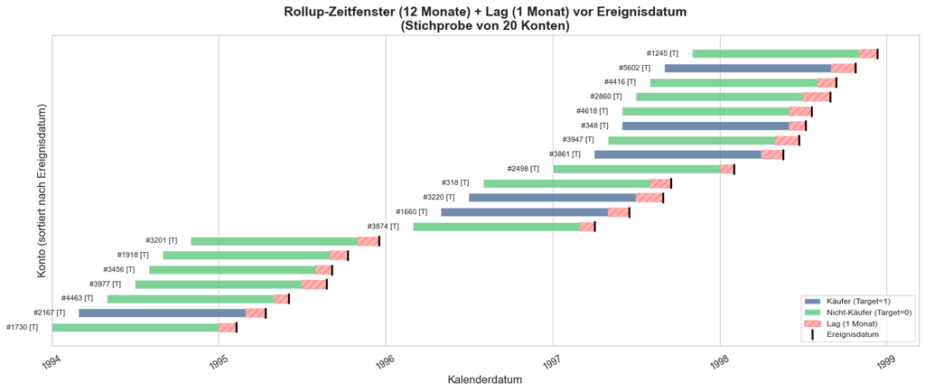

```python
# === Timeline-Visualisierung mit Lag-Gap ===

sample_accounts = study_table.sample(20, random_state=RANDOM_STATE).sort_values(
    "event_date"
)

fig, ax = plt.subplots(figsize=FIG_SIZE_DEFAULT)

for i, (_, row) in enumerate(sample_accounts.iterrows()):
    color = "C1" if row["target"] == 1 else "C4"

    # Rollup-Fenster: rollup_start bis rollup_end
    ax.barh(
        i,
        (row["rollup_end"] - row["rollup_start"]).days,
        left=row["rollup_start"],
        height=0.6,
        color=color,
        alpha=0.7,
        edgecolor="white",
    )

    # Lag-Gap: rollup_end bis event_date (rot, schraffiert)
    ax.barh(
        i,
        (row["event_date"] - row["rollup_end"]).days,
        left=row["rollup_end"],
        height=0.6,
        color="red",
        alpha=0.3,
        hatch="///",
        edgecolor="red",
        linewidth=0.5,
    )

    # Event-Datum als Marker
    ax.plot(row["event_date"], i, "k|", markersize=12, markeredgewidth=2)

    # Account-ID + Split Label
    split_label = row["split"][0].upper()  # T/V/T
    ax.text(
        row["rollup_start"] - pd.Timedelta(days=30),
        i,
        f"#{int(row['account_id'])} [{split_label}]",
        fontsize=8,
        va="center",
        ha="right",
    )

# Legende
legend_elements = [
    Patch(facecolor="C1", alpha=0.7, label="Käufer (Target=1)"),
    Patch(facecolor="C4", alpha=0.7, label="Nicht-Käufer (Target=0)"),
    Patch(
        facecolor="red",
        alpha=0.3,
        hatch="///",
        edgecolor="red",
        label=f"Lag ({LAG_MONTHS} Monat)",
    ),
    plt.Line2D(
        [0],
        [0],
        color="black",
        marker="|",
        linestyle="None",
        markersize=12,
        markeredgewidth=2,
        label="Ereignisdatum",
    ),
]
ax.legend(handles=legend_elements, loc="lower right")

ax.set_title(
    f"Rollup-Zeitfenster ({ROLLUP_MONTHS} Monate) + Lag ({LAG_MONTHS} Monat) vor Ereignisdatum\n(Stichprobe von 20 Konten)"
)
ax.set_xlabel("Kalenderdatum")
ax.set_ylabel("Konto (sortiert nach Ereignisdatum)")
ax.set_yticks([])
ax.tick_params(axis="x", rotation=30)

plt.tight_layout()
plt.show()
```

## 5.2 Zusammenfassung Studiendesign

### 5.2.1 Eligibility-Kriterien

1. **Konto-Inhaber:** Nur OWNERs (keine DISPONENTen)
2. **Alter:** >= 21 Jahre zum Ereigniszeitpunkt (keine Junior-Karten im Angebot)
3. **Kartentyp:** Nur `classic` und `gold` (keine `junior`)
4. **Rollup-Vollständigkeit:** Mindestens 13 Monate Transaktionshistorie vor dem Ereignisdatum (12M Rollup + 1M Lag)

### 5.2.2 Ereignisdatum-Zuweisung

- **Kartenbesitzer (Target=1):** Ereignisdatum = Kartenausstellungsdatum (`issued`)
- **Nicht-Kartenbesitzer (Target=0):** Pseudo-Ereignisdatum via Tenure-Matched Random Sampling aus der empirischen `months_to_event`-Verteilung der **Train-Card-Holders**

### 5.2.3 Rollup-Fenster + Lag

Für jedes Konto gilt: `[rollup_start ... rollup_end] [1 Monat Lag] [event_date]`

- **Rollup:** 12 Monate Feature-Aggregationszeitraum (min, max, mean, median, std, slope, MAD, etc.)
- **Lag:** 1 Monat Buffer verhindert Antragsmonat-Leakage

### 5.2.4 Train/Test Split

- **80/20** stratifiziert nach Target, durchgeführt **vor** der Pseudo-Event-Zuweisung
- Empirische Verteilung stammt ausschliesslich aus Train-Daten → kein Leakage in Test
- Klassenverhältnis konsistent über beide Splits (~13–16% Target=1)
- **Kein separates Validierungsset:** Modellselektion und Hyperparameter-Tuning erfolgen via stratifizierter k-Fold Cross-Validation auf dem Trainingsset

#### 5.2.4.1 In-Time vs. Out-of-Time

- **Gewählt:** **in-time**, zufälliger stratifizierter Random-Split (`sklearn.train_test_split(..., stratify=target)`). Train und Test stammen also aus demselben Kalenderzeitfenster.
- **Begründung:**
  - **Kleiner Datensatz** (n ≈ 3’900 Konten nach Eligibility) — ein out-of-time Cutoff würde das Testset auf ca. 150 Konten schrumpfen lassen, mit entsprechend instabilen Schätzern für ROC-AUC, Precision/Recall und Lift.
  - **Card-Events konzentrieren sich auf 1997/98** (siehe KDE der Event-Daten oben) — ein chronologischer Cutoff im oder vor diesem Fenster würde das Train/Test-Klassenverhältnis stark verzerren, da ein grosser Anteil der Positiven nur einseitig (links oder rechts vom Cutoff) verfügbar wäre.
  - **Tenure-Matching** (`months_to_event`-Sampling aus der Train-Verteilung) eliminiert bereits den **Immortal Time Bias**. Die zeitliche Synchronisation zwischen Käufern und Nicht-Käufern ist also schon strukturell hergestellt — der Kalendarzeit-Schutz, den ein out-of-time-Split zusätzlich liefert, ist hier weniger relevant.
- **Was wir damit aufgeben:** Keine direkte Simulation eines Produktions-Deployments mit Future-Cutoff (Concept Drift / Covariate Shift über die Zeit wird nicht explizit getestet). Für die Kampagnen-Empfehlung ist das vertretbar, weil das Modell auf einer **prioritisierten Liste (Top-N% Ranking)** basiert — eine relative Ordnung von Kunden, nicht eine kalenderbasierte Punktprognose. Die Schwächen eines in-time Splits (optimistische Schätzung bei zeitlich driftender Population) werden bei Bedarf in einer späteren Validierungsrunde mit frischen Daten adressiert.

### 5.2.5 Klassenungleichgewicht

Moderates Ungleichgewicht. Empfohlene Massnahmen beim Modeling:

- Stratifizierte k-Fold Cross-Validation auf dem Trainingsset
- Metriken: ROC-AUC, Precision, Recall, Lift
- Optional: Class Weights oder Oversampling (SMOTE)

```python
# === Studientabelle persistieren (für Phase 2: Feature Engineering) ===

os.makedirs("../data/processed", exist_ok=True)
study_table.to_parquet("../data/processed/study_table.parquet", index=False)
print(
    f"study_table gespeichert: {study_table.shape[0]} Zeilen, {study_table.shape[1]} Spalten"
)
print(f"  Pfad: ../data/processed/study_table.parquet")
```

```
study_table gespeichert: 3893 Zeilen, 8 Spalten
  Pfad: ../data/processed/study_table.parquet
```

# 6 Quellenverzeichnis

1. Berka, P. (1999). *PKDD’99 Discovery Challenge: Czech Financial Dataset*. Czech Technical University, Prague.
2. Her, Q., Getz, K., Engel, T. & Engel, A. (2024). Core Concepts in Pharmacoepidemiology: New-User Designs. *Clinical Therapeutics*, 46(12), e1–e6. https://pmc.ncbi.nlm.nih.gov/articles/PMC11588434/
3. Pottegård, A., Hallas, J., Olesen, M. et al. (2022). Core concepts in pharmacoepidemiology: Fundamentals of the cohort and case-control study designs. *Pharmacoepidemiology and Drug Safety*, 31(8), 817–826. https://pmc.ncbi.nlm.nih.gov/articles/PMC9545534/
4. Suissa, S. (2008). Immortal Time Bias in Pharmacoepidemiology. *American Journal of Epidemiology*, 167(4), 492–499. https://academic.oup.com/aje/article/167/4/492/233064